# C42B cells day1 and 5, comparing Ola 1 and 5.

Marion Hardy

2025-08-14

# Introduction

BulkRNAseq analysis of C42B cells treated with olaparib at different concentrations (1-5 uM?) for different amount of times (1-9 days).

This report will present a broad overview of how similar/different samples are in terms of gene expression. The objective is to help AK narrow down which gene sets are of interest and follow this with a gsea analysis and a closer look at the function of these identified gene groups.

Each sample comparison shown in this report will have additional files generated:

- res_tbl.csv = all differentially expressed genes, annotated (no filtering)
- Sign_genes.xlsx = excel doc with all significantly up- and down-regulated genes (log2Fc >= 1), annotated and sorted into all genes, only up and only down on different sheets.
- volcano plot of all genes (html format)

NB: Data quality has been checked within the previous script “DESeq2_1-18.R”, everything looked good.

# PCA

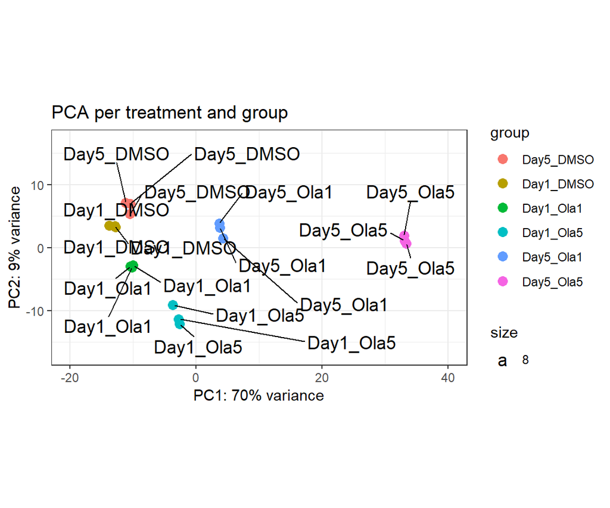

# Extract the weights per genes

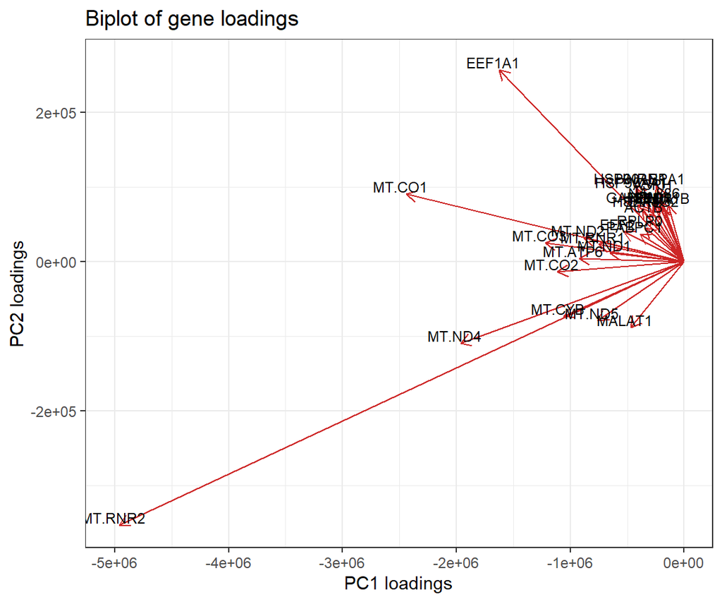

# Euclidian distances

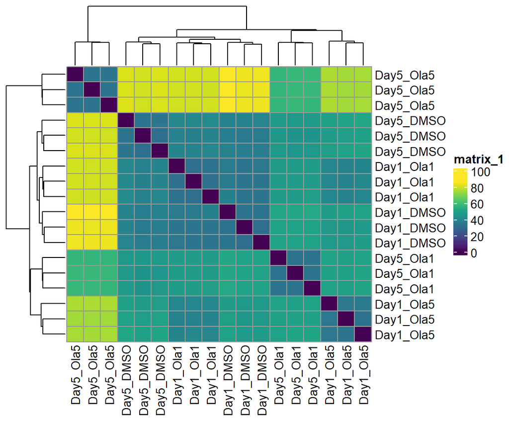

# Dendogram

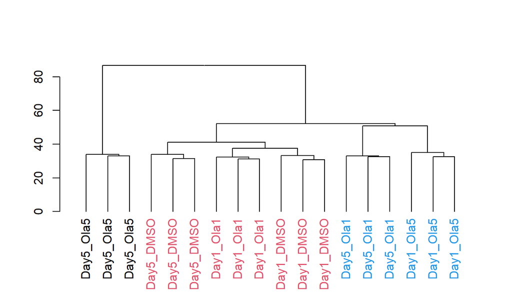

# Day1 Ola 1 and 5 vs DMSO

## Volcano plots

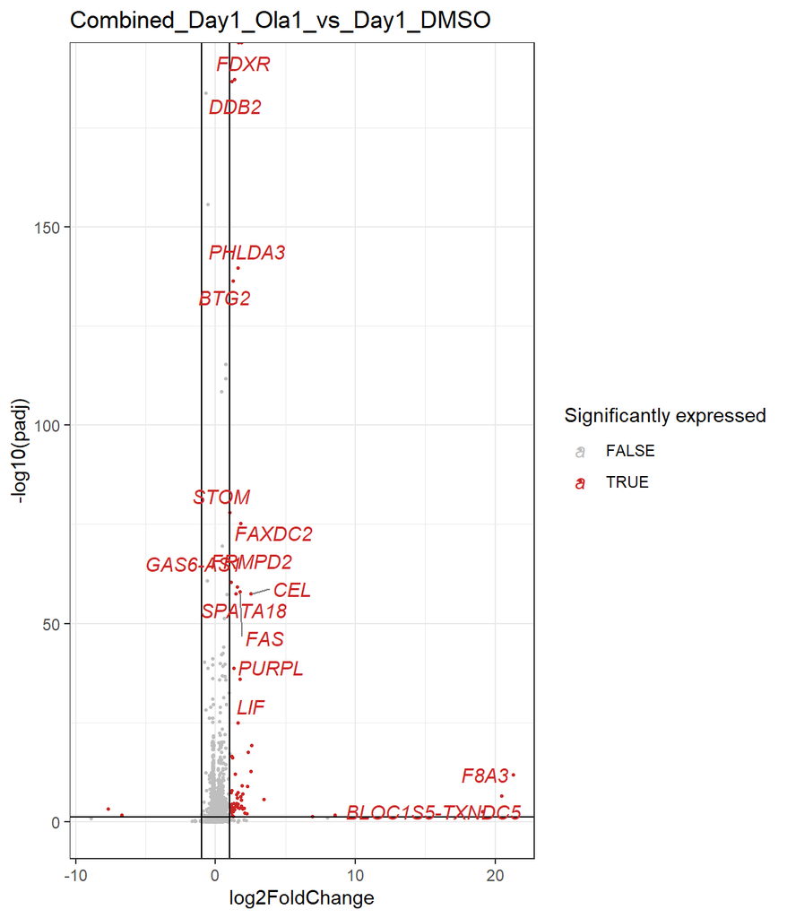

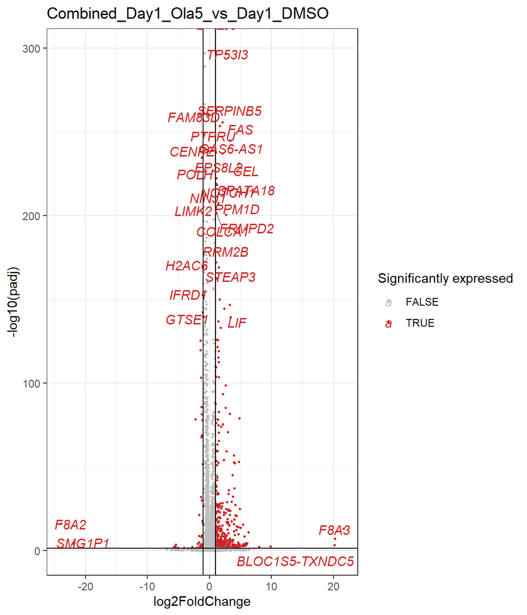

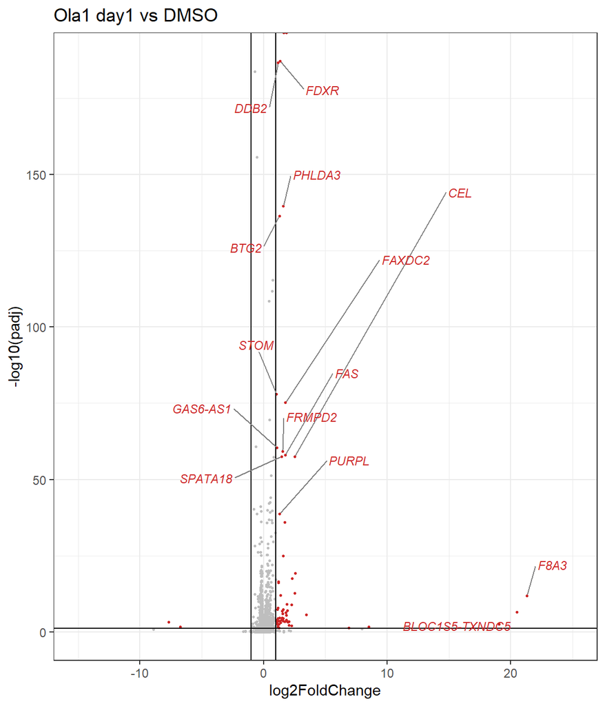

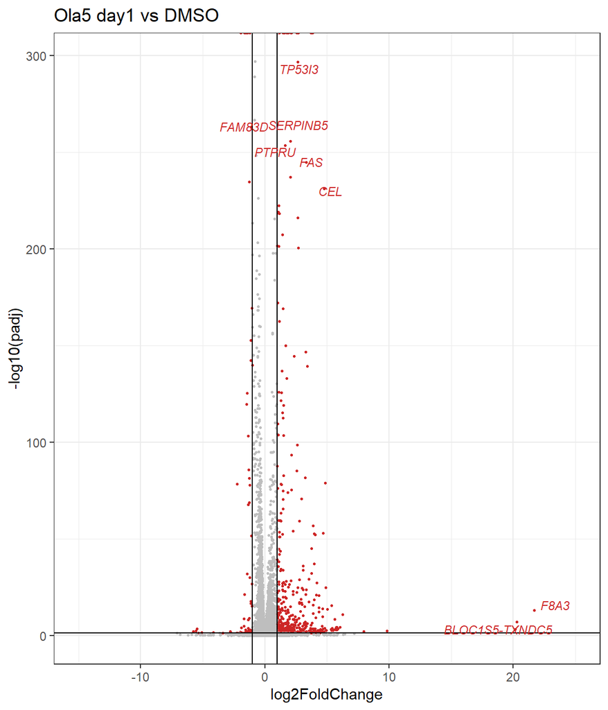

## GSEA Day1 Ola1

### GOBP

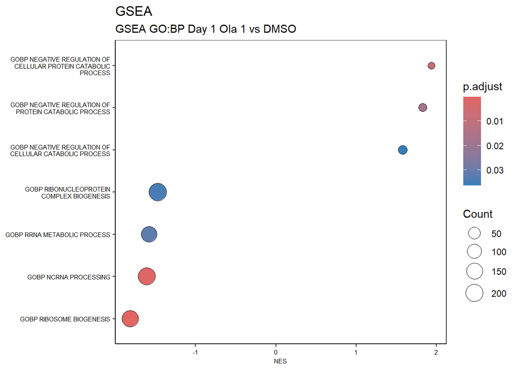

| ID | NES | setSize | p.adjust | qvalue | core_enrichment |
| --- | --- | --- | --- | --- | --- |
| GOBP_NEGATIVE_REGULATION_OF_CELLULAR_PROTEIN_CATABOLIC_PROCESS | 1.936278 | 72 | 0.0078350 | 0.0078350 | F8A3/MGAT3/PRKCG/EPHA4 |
| GOBP_NEGATIVE_REGULATION_OF_PROTEIN_CATABOLIC_PROCESS | 1.833178 | 111 | 0.0179338 | 0.0179338 | F8A3/MGAT3/PRKCG/SNCA/NOS2/EPHA4 |
| GOBP_NEGATIVE_REGULATION_OF_CELLULAR_CATABOLIC_PROCESS | 1.582213 | 240 | 0.0362614 | 0.0362614 | F8A3/MGAT3/PRKCG/RASIP1/SNCA/GDNF/BOLL/PIK3CG/EPHA4/RBM46/RGN |
| GOBP_RIBONUCLEOPROTEIN_COMPLEX_BIOGENESIS | -1.470352 | 411 | 0.0341575 | 0.0341575 | NVL/EXOSC10/LUC7L3/POLR2D/UTP3/METTL16/CPSF6/PWP1/MRPL20/GNL…… |
| GOBP_RRNA_METABOLIC_PROCESS | -1.577597 | 243 | 0.0316094 | 0.0316094 | NGDN/GTF3C4/NVL/EXOSC10/UTP3/METTL16/PWP1/YTHDF2/FCF1/BYSL/D…… |
| GOBP_NCRNA_PROCESSING | -1.607809 | 363 | 0.0013831 | 0.0013831 | NGDN/TSEN2/ELP1/NVL/EXOSC10/UTP3/METTL16/PWP1/YTHDF2/FCF1/ZB…… |
| GOBP_RIBOSOME_BIOGENESIS | -1.812367 | 280 | 0.0002046 | 0.0002046 | NGDN/NVL/EXOSC10/UTP3/METTL16/PWP1/MRPL20/GNL2/YTHDF2/FCF1/G…… |

### Hallmark

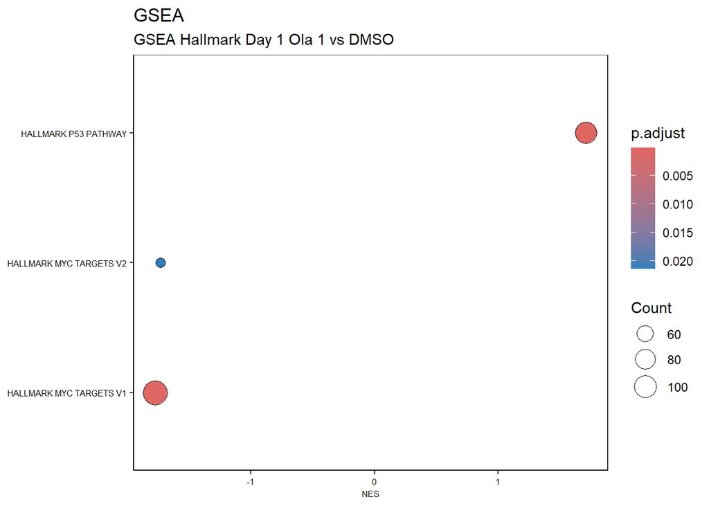

| ID | NES | setSize | p.adjust | qvalue | core_enrichment |
| --- | --- | --- | --- | --- | --- |
| HALLMARK_P53_PATHWAY | 1.711965 | 196 | 0.0001629 | 0.0001474 | KRT17/NHLH2/CCND2/CDKN1A/FAS/PHLDA3/LIF/IFI30/FDXR/SFN/BTG2/…… |
| HALLMARK_MYC_TARGETS_V2 | -1.729562 | 55 | 0.0213893 | 0.0193630 | SUPV3L1/SLC19A1/BYSL/TCOF1/TFB2M/GNL3/RABEPK/IMP4/HSPE1/HSPD…… |
| HALLMARK_MYC_TARGETS_V1 | -1.773559 | 186 | 0.0001371 | 0.0001241 | SMARCC1/YWHAQ/SF3B3/ORC2/PWP1/ILF2/CDC45/TOMM70/PSMA4/PSMD14…… |

## GSEA Day1 Ola5

### GOBP

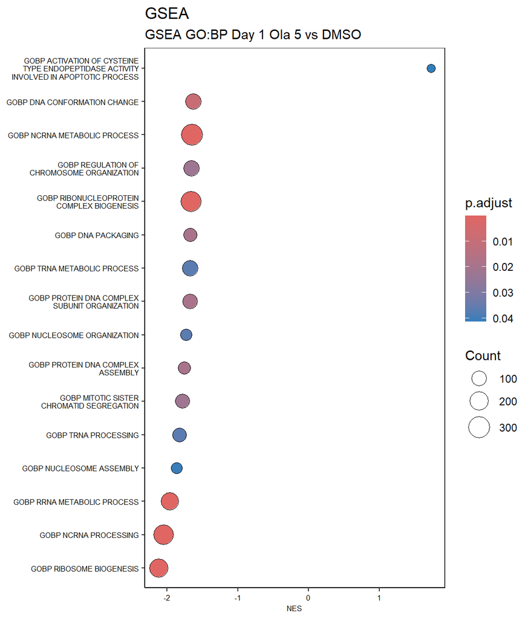

| ID | NES | setSize | p.adjust | qvalue | core_enrichment |
| --- | --- | --- | --- | --- | --- |
| GOBP_ACTIVATION_OF_CYSTEINE_TYPE_ENDOPEPTIDASE_ACTIVITY_INVOLVED_IN_APOPTOTIC_PROCESS | 1.730030 | 75 | 0.0412620 | 0.0392518 | NLRP1/BBC3/TNFSF15/SNCA/P2RX1/LAPTM5/MIR15A/RPS27L/NGFR/DLC1/SMAD3/CASP10/ACER2/BAX/ATP2A3/S100A9/FASLG/CASP1/PIDD1/XDH/KHDC1L/BCL2L10/PML/LCK/PMAIP1/PPARG/SLC1A1/CASP4/SLC22A2/F2R/APAF1 |
| GOBP_DNA_CONFORMATION_CHANGE | -1.627468 | 299 | 0.0083779 | 0.0079698 | CTCF/DNMT1/DSCC1/HIRA/BAZ2A/SMC2/HMGA1/AXIN1/CHD4/XRCC6/XRCC…… |
| GOBP_NCRNA_METABOLIC_PROCESS | -1.647546 | 493 | 0.0000429 | 0.0000408 | TRMT5/DDX49/CT45A1/DROSHA/ELP1/MEPCE/EXOSC2/EPRS1/TRUB1/AARS…… |
| GOBP_REGULATION_OF_CHROMOSOME_ORGANIZATION | -1.658160 | 198 | 0.0221652 | 0.0210853 | ANAPC7/CDK5RAP2/XRCC3/RAD50/INO80C/SLF1/ZWILCH/SMG1/PCID2/RE…… |
| GOBP_RIBONUCLEOPROTEIN_COMPLEX_BIOGENESIS | -1.661353 | 411 | 0.0001786 | 0.0001699 | NSUN4/RPP40/RRP8/TRAF7/AAR2/PSIP1/HELQ/POP4/LUC7L3/FASTKD2/M…… |
| GOBP_DNA_PACKAGING | -1.672070 | 207 | 0.0190372 | 0.0181098 | SMCHD1/H2BC21/NCAPD3/PPHLN1/OIP5/MBD2/TTN/SELENOF/NOC2L/H4C5/KDM1A/ASF1A/NUSAP1/H4C11/BAZ1B/ANP32B/H3-3B/SRPK1/SUV39H1/H2BC5/H4C2/H3C12/TRIM28/H1-2/H2BC15/H1-10/RIF1/CBX3/SET/MIS18A/CHRAC1/SMARCA5/BEN… |
| GOBP_TRNA_METABOLIC_PROCESS | -1.673581 | 176 | 0.0366030 | 0.0348198 | LCMT2/DTD1/TRMT5/ELP1/EXOSC2/EPRS1/TRUB1/AARS1/TRMT10A/RTRAF…… |
| GOBP_PROTEIN_DNA_COMPLEX_SUBUNIT_ORGANIZATION | -1.677120 | 210 | 0.0190372 | 0.0181098 | SMARCC1/MYC/TERF1/YY1/SUPT16H/SOX9/CENPX/POLR1E/BRF2/SYCP3/K…… |
| GOBP_NUCLEOSOME_ORGANIZATION | -1.730789 | 140 | 0.0366030 | 0.0348198 | ASF1A/ANP32E/H4C11/SSRP1/ANP32B/H3-3B/H2BC5/H4C2/H3C12/H1-2/H2BC15/ACTL6A/H1-10/SET/MIS18A/UCHL5/CHRAC1/SMARCA5/NPM1/H4C8/NAP1L6P/H2BC6/H2BC14/SETSIP/H3C15/H3C2/H1-4/H3C1/H2BC13/HMGB2/H2BC7/H2AX/H2BC4… |
| GOBP_PROTEIN_DNA_COMPLEX_ASSEMBLY | -1.756993 | 165 | 0.0190372 | 0.0181098 | CENPO/HMGB1/H2BC21/OIP5/H4C5/ASF1A/CENPI/H4C11/TBP/ANP32B/H3-3B/H2BC5/TAF5/H4C2/H3C12/TAF7L/H1-2/H2BC15/H1-10/SET/MIS18A/CHRAC1/SMARCA5/NPM1/H4C8/NAP1L6P/WNT10B/H2BC6/H2BC14/SETSIP/H3C15/H3C2/H1-4/H3C… |
| GOBP_MITOTIC_SISTER_CHROMATID_SEGREGATION | -1.780740 | 169 | 0.0220604 | 0.0209857 | CDC23/HASPIN/NAA10/APC/CDC26/NUP62/VPS4A/PSMG2/DSCC1/SMC2/PD…… |
| GOBP_TRNA_PROCESSING | -1.822738 | 120 | 0.0366030 | 0.0348198 | LCMT2/TRMT5/ELP1/TRUB1/AARS1/TRMT10A/RTRAF/RPP40/POP4/THADA/…… |
| GOBP_NUCLEOSOME_ASSEMBLY | -1.864136 | 97 | 0.0407495 | 0.0387643 | H4C11/ANP32B/H3-3B/H2BC5/H4C2/H3C12/H1-2/H2BC15/H1-10/SET/MIS18A/CHRAC1/SMARCA5/NPM1/H4C8/NAP1L6P/H2BC6/H2BC14/SETSIP/H3C15/H3C2/H1-4/H3C1/H2BC13/HMGB2/H2BC7/H2AX/H2BC4/H1-0/HJURP/H4C14/H2BC12/H2BC17/… |
| GOBP_RRNA_METABOLIC_PROCESS | -1.964336 | 243 | 0.0000108 | 0.0000102 | UTP3/METTL5/RPF1/TAF1B/NSUN4/RPP40/RRP8/HELQ/GTF3C4/POP4/MRM…… |
| GOBP_NCRNA_PROCESSING | -2.050039 | 363 | 0.0000000 | 0.0000000 | TRMT5/DDX49/CT45A1/DROSHA/ELP1/EXOSC2/TRUB1/AARS1/UTP3/METTL…… |
| GOBP_RIBOSOME_BIOGENESIS | -2.119689 | 280 | 0.0000000 | 0.0000000 | NSUN4/RPP40/RRP8/TRAF7/HELQ/POP4/FASTKD2/MRM2/NVL/GNL2/RBFA/…… |

### Reactome

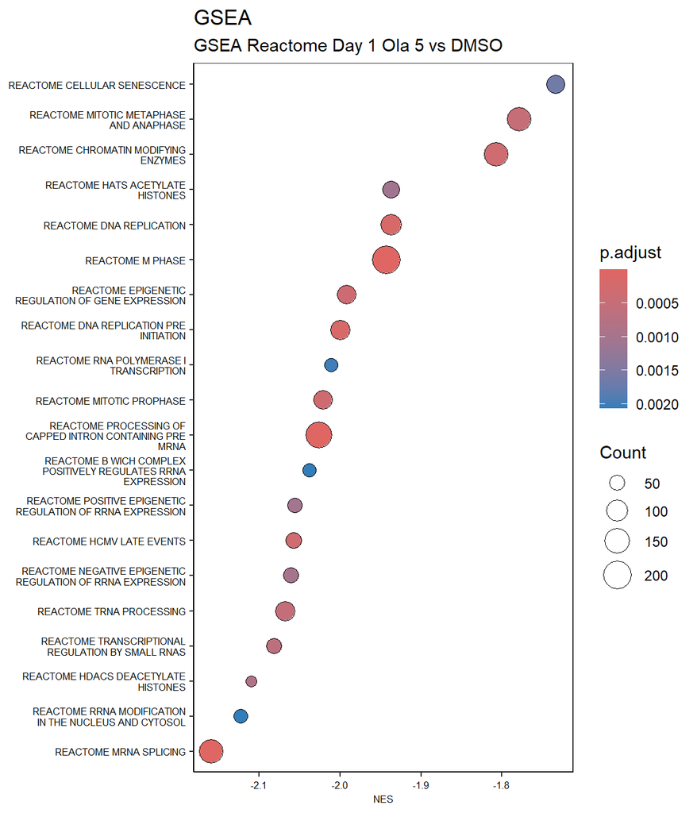

| ID | NES | setSize | p.adjust | qvalue | core_enrichment |
| --- | --- | --- | --- | --- | --- |
| REACTOME_DAP12_INTERACTIONS | 1.696706 | 33 | 0.0274913 | 0.0237546 | SIGLEC14/CD300LB/KLRK1/SIGLEC15/TREM2/LCP2/GRAP2/BTK/LAT/PLCG2/LCK |
| REACTOME_MOLECULES_ASSOCIATED_WITH_ELASTIC_FIBRES | 1.663611 | 36 | 0.0359395 | 0.0310544 | GDF5/FBN2/MFAP4/EFEMP2/LTBP2/FBN3/EMILIN3/FBN1/FBLN1/EFEMP1 |
| REACTOME_DISEASES_ASSOCIATED_WITH_O_GLYCOSYLATION_OF_PROTEINS | 1.662817 | 55 | 0.0222802 | 0.0192518 | ADAMTSL2/MUC12/THSD1/SBSPON/ADAMTS5/SEMA5B/ADAMTS7/ADAMTS14/MUC3A/ADAMTS6/NOTCH1/SEMA5A/MUC17/ADAMTS9/THSD4/MUC13/ADAMTSL4/NOTCH3/SSPOP/ADAMTSL5 |
| REACTOME_ELASTIC_FIBRE_FORMATION | 1.647515 | 43 | 0.0340401 | 0.0294132 | GDF5/FBN2/MFAP4/EFEMP2/LTBP2/LOXL4/FBN3/EMILIN3/FBN1/FBLN1/EFEMP1 |
| REACTOME_ARACHIDONIC_ACID_METABOLISM | 1.627034 | 54 | 0.0291984 | 0.0252296 | CYP4B1/CYP1A2/DPEP1/HPGDS/ALOX5AP/CYP4F3/CYP4F2/PTGS2/PTGS1/GPX2/CYP4F22/CYP4A11/ALOX12B/ALOX15B/CYP4F11/GPX1/CYP4F8/CYP1A1/PTGES |
| REACTOME_STIMULI_SENSING_CHANNELS | 1.563628 | 95 | 0.0334682 | 0.0289191 | TRPV2/CASQ1/TRPC7/STOM/CLCNKB/ANO1/TRPM3/SLC9C2/SCNN1G/TRPV4…… |
| REACTOME_EXTRACELLULAR_MATRIX_ORGANIZATION | 1.537113 | 274 | 0.0020588 | 0.0017790 | NID1/COL17A1/SERPINE1/CEACAM1/GDF5/COL5A1/PECAM1/ITGAM/MUSK/…… |
| REACTOME_DEGRADATION_OF_THE_EXTRACELLULAR_MATRIX | 1.520388 | 122 | 0.0359395 | 0.0310544 | NID1/COL17A1/COL5A1/FBN2/TMPRSS6/CAPN11/COL10A1/ADAMTS5/OPTC…… |
| REACTOME_ION_CHANNEL_TRANSPORT | 1.475198 | 168 | 0.0340401 | 0.0294132 | TRPV2/FXYD2/CASQ1/TRPC7/FXYD6/ATP13A4/ATP10D/STOM/CLCNKB/ANO…… |
| REACTOME_RHO_GTPASE_EFFECTORS | -1.400605 | 301 | 0.0379185 | 0.0327644 | CENPC/PFN1/PKN1/PPP1R12A/CLASP2/YWHAG/SKA2/DIAPH1/MEN1/MAPK1…… |
| REACTOME_G2_M_CHECKPOINTS | -1.522093 | 147 | 0.0499489 | 0.0431595 | PSMD9/PSMC3/SUMO1/PSMD8/RAD1/PSMF1/PIAS4/PSMB5/KAT5/PSMB7/PS…… |
| REACTOME_TRANSLATION | -1.584395 | 278 | 0.0022904 | 0.0019791 | MRPL11/MRPL42/MRPS24/PABPC1/TSFM/HARS1/EIF3D/DAP3/CHCHD1/EIF…… |
| REACTOME_CELL_CYCLE_CHECKPOINTS | -1.612018 | 266 | 0.0026287 | 0.0022714 | PSMA6/MCM2/PSMA1/MCM5/UBC/PAFAH1B1/CDKN1B/MCM4/CDK1/PSMC5/ND…… |
| REACTOME_MITOTIC_PROMETAPHASE | -1.623305 | 189 | 0.0060240 | 0.0052052 | CEP78/PPP2R1A/TUBGCP2/CEP43/CEP192/CENPC/CLASP2/YWHAG/SKA2/M…… |
| REACTOME_RESOLUTION_OF_SISTER_CHROMATID_COHESION | -1.642327 | 121 | 0.0435123 | 0.0375978 | MAPRE1/PPP2R5C/PPP2R1B/KIF2A/PPP2CA/TUBA3D/PDS5A/DYNLL2/WAPL…… |
| REACTOME_TELOMERE_MAINTENANCE | -1.655561 | 99 | 0.0493151 | 0.0426119 | DSCC1/H2AC14/POLR2B/RUVBL2/PPP6R3/POT1/H2BC21/SHQ1/WRAP53/H4C5/H4C11/H3-3B/H2BC5/H4C2/H2BC15/H2AZ1/DKC1/GAR1/H4C8/H2BC6/TERT/H2AC20/H2BC14/H2BC13/H2BC7/H2AX/H2BC4/CCNA1/CCNA2/H4C14/H2BC12/H2AC8/H2BC17… |
| REACTOME_RRNA_PROCESSING | -1.686332 | 191 | 0.0020879 | 0.0018041 | NOL12/NSUN4/RPP40/MRM2/RPL36AL/EXOSC10/DIS3/RPL24/EXOSC9/IMP…… |
| REACTOME_CHROMOSOME_MAINTENANCE | -1.688024 | 126 | 0.0141604 | 0.0122356 | DSCC1/H2AC14/POLR2B/RUVBL2/PPP6R3/POT1/CENPO/H2BC21/OIP5/SHQ1/WRAP53/H4C5/CENPI/H4C11/H3-3B/H2BC5/H4C2/H2BC15/H2AZ1/MIS18A/SMARCA5/NPM1/CENPL/DKC1/GAR1/KNL1/H4C8/H2BC6/TERT/H2AC20/MIS18BP1/H2BC14/H2BC… |
| REACTOME_SEPARATION_OF_SISTER_CHROMATIDS | -1.693529 | 178 | 0.0022904 | 0.0019791 | NUP43/NUP107/PSMD13/ZWILCH/CENPN/STAG2/PSMA6/PSMA1/UBC/PAFAH…… |
| REACTOME_BASE_EXCISION_REPAIR_AP_SITE_FORMATION | -1.696132 | 52 | 0.0487425 | 0.0421172 | POT1/H2BC21/H4C5/H4C11/NEIL2/H2BC5/H4C2/H2BC15/H2AZ1/NTHL1/H4C8/H2BC6/H2AC20/H2BC14/H2BC13/H2BC7/NEIL3/H2AX/H2BC4/H4C14/H2BC12/H2AC8/H2BC17/H2AC7/H2AC6/H4C15/H2BC11/H2BC8/H2AC4 |
| REACTOME_RHO_GTPASES_ACTIVATE_PKNS | -1.698750 | 80 | 0.0435123 | 0.0375978 | H2BC21/YWHAH/H4C5/KDM1A/KLK3/H4C11/H3-3B/H2BC5/H4C2/H3C12/H2BC15/H2AZ1/H4C8/H2BC6/H2AC20/H2BC14/H3C15/H3C2/H3C1/H2BC13/H2BC7/H2AX/H2BC4/H4C14/H2BC12/H2AC8/H2BC17/H2AC7/H3C10/H2AC6/H4C15/H2BC11/H2BC8/H… |
| REACTOME_GENE_SILENCING_BY_RNA | -1.720654 | 124 | 0.0141604 | 0.0122356 | SEC13/NUP188/NUP54/NUP160/NUP153/H2BC21/AGO2/H4C5/XPO5/NUP50/ELAC2/NUP37/NUP88/POM121/NUP205/H4C11/H3-3B/H2BC5/SEH1L/H4C2/H3C12/NUP98/NUP58/RAN/H2BC15/NDC1/H2AZ1/HSP90AA1/TDRD12/H4C8/H2BC6/H2AC20/H2BC… |
| REACTOME_NEGATIVE_REGULATION_OF_NOTCH4_SIGNALING | -1.720696 | 46 | 0.0457613 | 0.0395412 | PSMD9/PSMC3/PSMD8/PSMF1/PSMB5/PSMB7/PSMA2/PSMB6/PSMD1/PSMD13…… |
| REACTOME_DEGRADATION_OF_DVL | -1.727345 | 49 | 0.0379185 | 0.0327644 | PSMD9/PSMC3/PSMD8/PSMF1/PSMB5/PSMB7/PSMA2/PSMB6/PSMD1/PSME4/…… |
| REACTOME_UCH_PROTEINASES | -1.731958 | 87 | 0.0312399 | 0.0269936 | PSMD9/PSMC3/BAP1/PSMD8/PSMF1/PSMB5/PSMB7/PSMA2/PSMB6/PSMD1/H…… |
| REACTOME_CELLULAR_SENESCENCE | -1.733493 | 174 | 0.0016440 | 0.0014206 | RPS6KA3/ID1/HIRA/HMGA1/H2AC14/FZR1/ERF/UBE2D1/POT1/CDKN2A/ETS2/H2BC21/CBX2/H4C5/E2F3/ASF1A/CBX4/H4C11/H3-3B/ANAPC1/H2BC5/H4C2/H3C12/CBX8/BMI1/RNF2/CDKN2C/H1-2/NBN/H2BC15/H2AZ1/TNIK/ANAPC10/CDC27/LMNB1… |
| REACTOME_MRNA_SPLICING_MINOR_PATHWAY | -1.744891 | 49 | 0.0334682 | 0.0289191 | SNRNP35/POLR2J/ZCRB1/POLR2E/DDX42/SF3B6/SNRNP200/SF3B5/PRPF6…… |
| REACTOME_HCMV_INFECTION | -1.753626 | 146 | 0.0060240 | 0.0052052 | H2AC14/NUP93/TBL1XR1/DYNLL2/CHMP2B/DYNC1LI1/SEC13/DYNLL1/NUP…… |
| REACTOME_RECOGNITION_AND_ASSOCIATION_OF_DNA_GLYCOSYLASE_WITH_SITE_CONTAINING_AN_AFFECTED_PURINE | -1.775435 | 45 | 0.0358869 | 0.0310089 | POT1/H2BC21/H4C5/H4C11/H2BC5/H4C2/H2BC15/H2AZ1/H4C8/H2BC6/H2AC20/H2BC14/H2BC13/H2BC7/NEIL3/H2AX/H2BC4/H4C14/H2BC12/H2AC8/H2BC17/H2AC7/H2AC6/H4C15/H2BC11/H2BC8/H2AC4 |
| REACTOME_MITOTIC_METAPHASE_AND_ANAPHASE | -1.778764 | 221 | 0.0004900 | 0.0004234 | UBE2I/STAG2/PSMA6/PSMA1/UBC/PAFAH1B1/PDS5B/CDK1/PSMC5/NDEL1/…… |

[output cut: 62 more lines]

### Hallmark

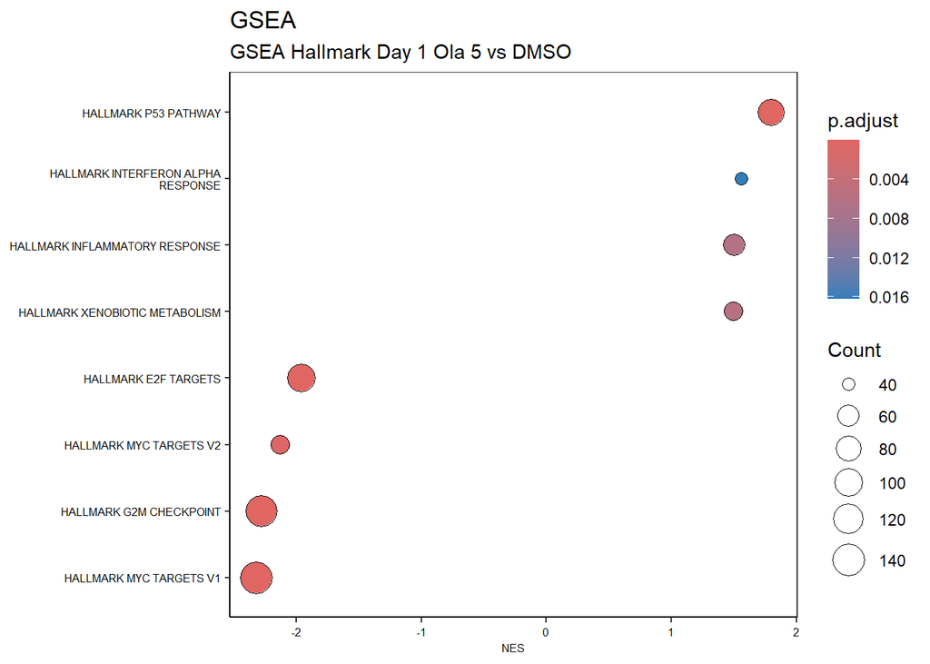

| ID | NES | setSize | p.adjust | qvalue | core_enrichment |
| --- | --- | --- | --- | --- | --- |
| HALLMARK_P53_PATHWAY | 1.800464 | 196 | 0.0000003 | 0.0000003 | KRT17/CDKN1A/LIF/FAS/SFN/NHLH2/PHLDA3/IFI30/FDXR/BTG2/CCND2/…… |
| HALLMARK_INTERFERON_ALPHA_RESPONSE | 1.560874 | 84 | 0.0161718 | 0.0125969 | IFI30/IL15/LAMP3/IFIT3/CSF1/PROCR/OAS1/GBP4/TENT5A/NMI/CD74/…… |
| HALLMARK_INFLAMMATORY_RESPONSE | 1.505833 | 175 | 0.0060567 | 0.0047178 | CD70/SERPINE1/CDKN1A/LIF/TNFRSF9/ABCA1/IL15/TNFSF15/BTG2/AXL…… |
| HALLMARK_XENOBIOTIC_METABOLISM | 1.496819 | 182 | 0.0058520 | 0.0045584 | LCAT/ALDH3A1/SERPINE1/FETUB/FAS/FMO3/SLC12A4/CYP1A2/IRF8/ADH…… |
| HALLMARK_E2F_TARGETS | -1.959728 | 194 | 0.0000009 | 0.0000007 | CTCF/DNMT1/DSCC1/BARD1/SNRPB/TIPIN/HUS1/DIAPH3/HMGA1/CHEK2/X…… |
| HALLMARK_MYC_TARGETS_V2 | -2.127466 | 55 | 0.0005139 | 0.0004003 | MCM5/MCM4/MYC/PA2G4/RCL1/SUPV3L1/SORD/TMEM97/GRWD1/BYSL/WDR4…… |
| HALLMARK_G2M_CHECKPOINT | -2.278018 | 196 | 0.0000000 | 0.0000000 | LIG3/SRSF10/TFDP1/CKS1B/ORC5/MAP3K20/DR1/CTCF/BARD1/CDC7/HIR…… |
| HALLMARK_MYC_TARGETS_V1 | -2.323779 | 186 | 0.0000000 | 0.0000000 | COPS5/LSM7/PSMA6/MCM2/PSMA1/MCM5/SNRPG/MCM4/IARS1/SMARCC1/MY…… |

### Summary

```
##
## FALSE
## 38179
```

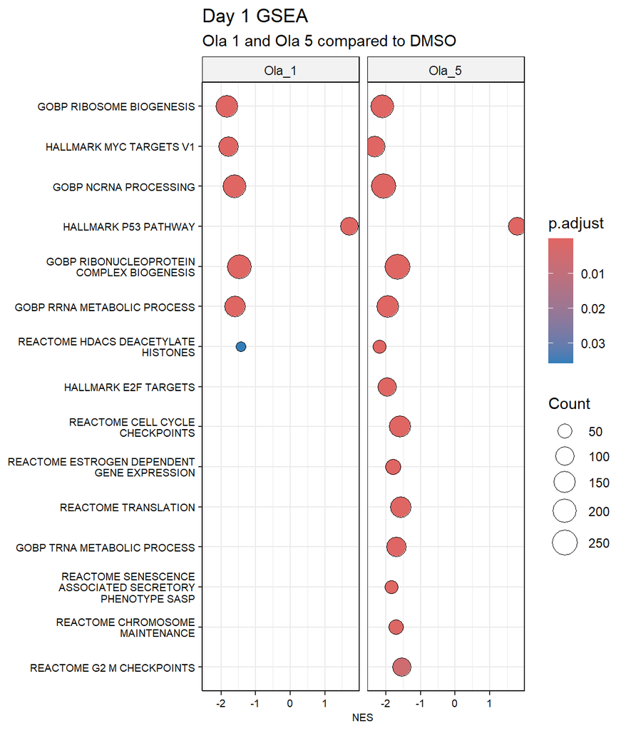

# Day 5 Ola 1 and 5 vs DMSO

## Volcano plots

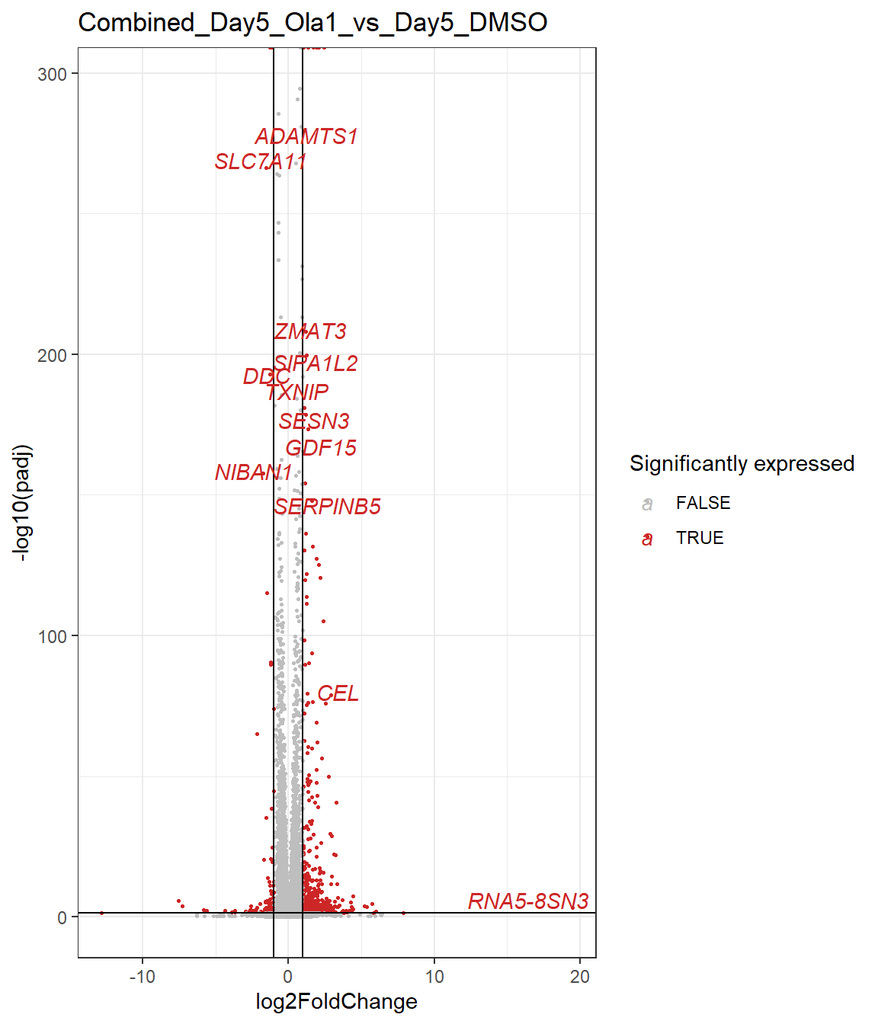

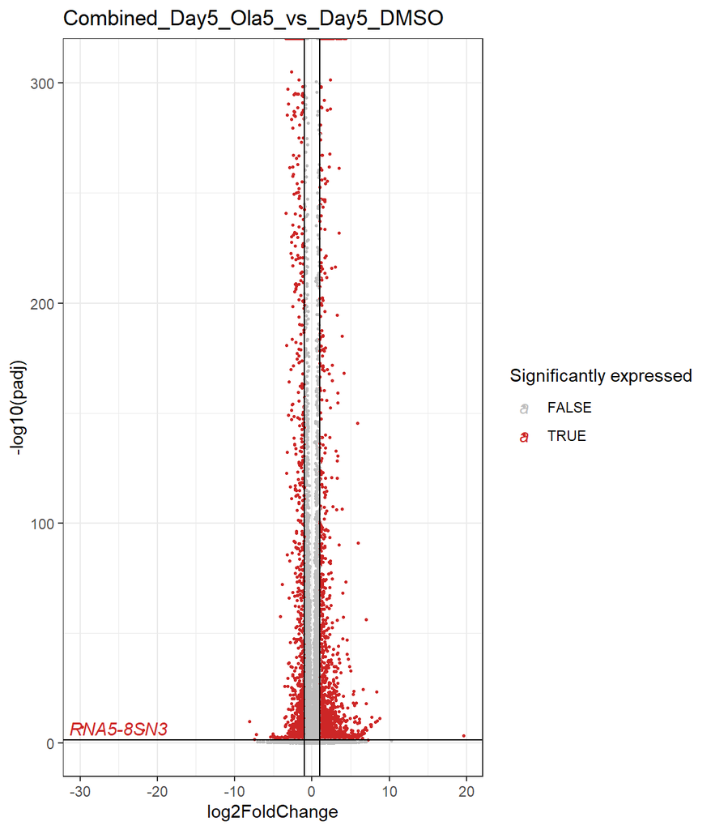

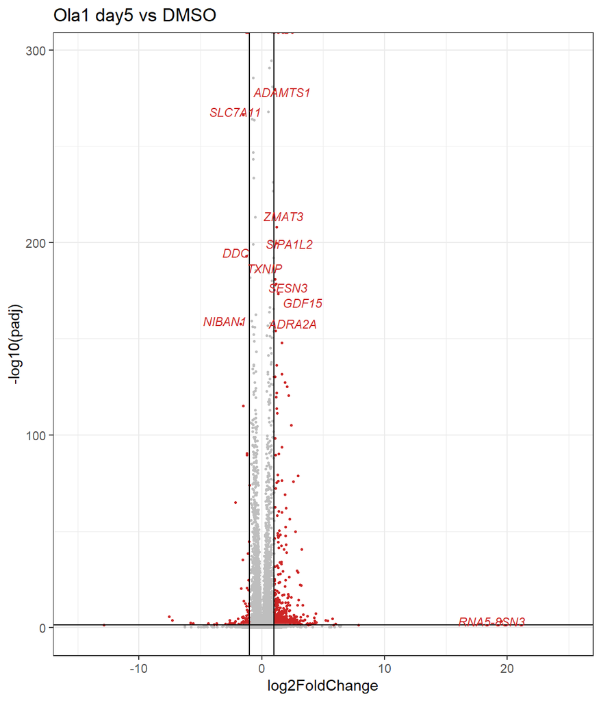

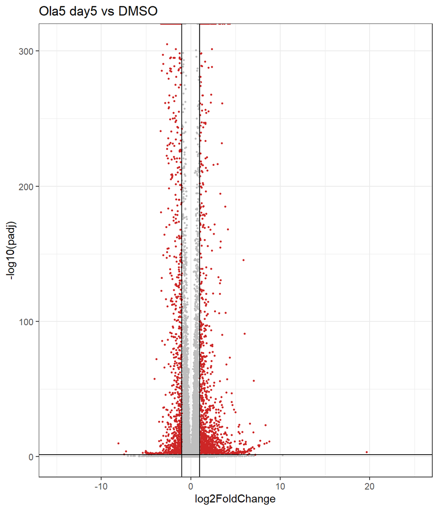

## GSEA Day5 Ola1

### GOBP

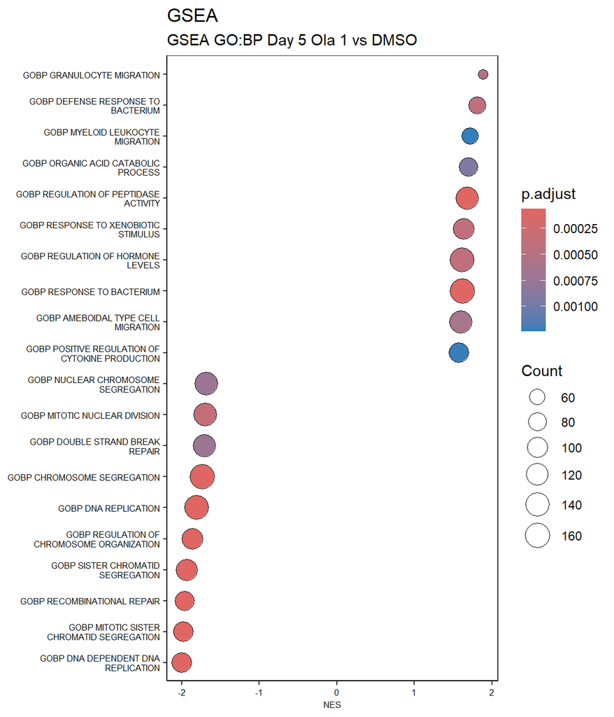

| ID | NES | setSize | p.adjust | qvalue | core_enrichment |
| --- | --- | --- | --- | --- | --- |
| GOBP_CELLULAR_DEFENSE_RESPONSE | 1.936023 | 40 | 0.0030484 | 0.0026600 | CXCR2/LY96/CCR9/NCF2/CXCL9/IL1RL2/NCF1/CCR3/DCDC2/CD5L/CD300C/C5AR1/ADORA2A/IL33/CCR2/PRF1/KLRC2 |
| GOBP_GRANULOCYTE_MIGRATION | 1.881710 | 125 | 0.0005025 | 0.0004384 | CXCR2/CCL26/PECAM1/CD300H/CXCR1/S100A14/ANXA1/XG/THBS1/CXCL1…… |
| GOBP_OXIDATIVE_DEMETHYLATION | 1.870688 | 18 | 0.0101346 | 0.0088431 | CYP3A4/CYP3A5/CYP1A2/CYP3A43/CYP3A7 |
| GOBP_AMINE_TRANSPORT | 1.863365 | 86 | 0.0018497 | 0.0016140 | DRD2/TH/ACE2/CHRNB2/SYT2/CNR1/RGS4/KCNB1/SYT17/SYT4/KCNA2/SV…… |
| GOBP_XENOBIOTIC_CATABOLIC_PROCESS | 1.855705 | 22 | 0.0107922 | 0.0094170 | CYP3A4/CYP3A5/CYP1A2/GSTM1/PON3/CYP2A6/GSTM2/CYP1A1/NR1I2/NOS1 |
| GOBP_CATECHOLAMINE_SECRETION | 1.853191 | 48 | 0.0065663 | 0.0057296 | DRD2/CHRNB2/SYT2/CNR1/KCNB1/SYT17/SYT4/KCNA2/SYT13/SYT3/GDNF/SYT9/SNCG/CHRNA4/ADORA2A/ADRA2A/CARTPT/FFAR3/SYT10/PRKN/SYT6/ABAT/AGT/SYT1/HRH3/PINK1/SYT7 |
| GOBP_DOPAMINE_TRANSPORT | 1.853019 | 42 | 0.0056192 | 0.0049032 | DRD2/CHRM5/CHRNB2/SYT2/CNR1/SYT17/SYT4/KCNA2/SYT13/SYT3/GDNF/SYT9/SNCG/CHRNA4/SYT10/PRKN/SYT6/SLC29A4/ABAT/SYT1/PINK1/SYT7 |
| GOBP_GRANULOCYTE_CHEMOTAXIS | 1.852895 | 100 | 0.0013010 | 0.0011352 | CXCR2/CCL26/CD300H/CXCR1/S100A14/ANXA1/THBS1/CXCL10/CCL21/CX…… |
| GOBP_RETINOL_METABOLIC_PROCESS | 1.845667 | 45 | 0.0107922 | 0.0094170 | DHRS9/CYP3A4/CYP3A5/CYP1A2/ADH7/ADH4/ADH6/AKR1B10/RBP4/AKR1C3/AWAT2/TTR/CYP3A7/PLB1/BCO1/CYP1A1 |
| GOBP_REGULATION_OF_CALCIUM_ION_DEPENDENT_EXOCYTOSIS | 1.838805 | 36 | 0.0185166 | 0.0161571 | SYT2/KCNB1/SYT17/SYT4/SYT13/SYT3/SYT9/CACNA1G/CACNA1I/ADRA2A/SYT10/SYT6/CDK5R2/CACNA1H/NOTCH1/SYT1/SYT7/DOC2A/BAIAP3/SCAMP5 |
| GOBP_NEUTROPHIL_MIGRATION | 1.831100 | 102 | 0.0018497 | 0.0016140 | CXCR2/CCL26/PECAM1/CD300H/CXCR1/XG/CXCL10/CCL21/CXCL9/CCL17/…… |
| GOBP_DOPAMINE_SECRETION | 1.825119 | 32 | 0.0215263 | 0.0187833 | DRD2/CHRNB2/SYT2/CNR1/SYT17/SYT4/KCNA2/SYT13/SYT3/GDNF/SYT9/SNCG/CHRNA4/SYT10/PRKN/SYT6/ABAT/SYT1/PINK1/SYT7 |
| GOBP_NEUTROPHIL_CHEMOTAXIS | 1.822304 | 80 | 0.0027663 | 0.0024138 | CXCR2/CCL26/CD300H/CXCR1/CXCL10/CCL21/CXCL9/CCL17/S100A9/EDN…… |
| GOBP_MEMORY | 1.818699 | 105 | 0.0019764 | 0.0017245 | MUSK/DRD2/TH/KLK8/CHRNB2/SLC8A3/GRIN2A/CNR1/PAK5/DBH/SYT4/PT…… |
| GOBP_REGULATION_OF_DENDRITE_EXTENSION | 1.816214 | 23 | 0.0216317 | 0.0188752 | RASAL1/CPNE9/SYT2/SYT17/CPNE5/SYT4/SYT3/RIMS2/PRKN/CXCR4/UNC13A/SYT1 |
| GOBP_MONOAMINE_TRANSPORT | 1.813605 | 69 | 0.0070360 | 0.0061394 | DRD2/CHRM5/CHRNB2/SYT2/CNR1/KCNB1/SYT17/SYT4/ITGB3/KCNA2/SYT13/SYT3/GDNF/SYT9/SNCG/CHRNA4/ADORA2A/ADRA2A/CARTPT/NOS1/FFAR3/SYT10/PRKN/SYT6/SLC29A4/ABAT/SLC6A4/AGT/SYT1/HRH3/PINK1/SYT7 |
| GOBP_XENOBIOTIC_METABOLIC_PROCESS | 1.810704 | 98 | 0.0034547 | 0.0030145 | UGT1A10/UGT1A3/CYP2W1/CYP3A4/CYP3A5/SULT1B1/CYP1A2/GSTM1/NAT…… |
| GOBP_DEFENSE_RESPONSE_TO_BACTERIUM | 1.806339 | 186 | 0.0004036 | 0.0003522 | NLRP1/ADAMTS5/WFDC10B/RNASE7/DMBT1/TLR4/ZG16/HAMP/TLR9/GBP6/…… |
| GOBP_ORGANIC_HYDROXY_COMPOUND_CATABOLIC_PROCESS | 1.805465 | 73 | 0.0054307 | 0.0047387 | FGF23/HAO1/CYP3A4/CEL/SULT1B1/ADH4/DIO2/AKR1B10/AKR1C3/CYP4F3/MOXD1/CYP4F12/DBH/CYP4F2/DIO3/SULT1C4 |
| GOBP_T_CELL_MIGRATION | 1.779647 | 52 | 0.0186749 | 0.0162952 | CCL26/ZAP70/XG/CXCL10/CCL21/MYO1G/APOD/CXCL11/CCR2/PIK3CG/CD200/TNFSF14/XCL2/AIRE |
| GOBP_ISOPRENOID_METABOLIC_PROCESS | 1.776530 | 105 | 0.0037356 | 0.0032595 | UGT1A3/CYP2W1/DHRS9/CYP3A4/CYP3A5/TH/CYP1A2/ADH7/ADH4/ADH6/AKR1B10/RBP4/AKR1C3/AWAT2/TTR/ABCA4/IDI2/CYP3A7/PLB1/BCO1/CYP1A1/ALDH8A1 |
| GOBP_REGULATION_OF_SKELETAL_MUSCLE_CONTRACTION | 1.775845 | 16 | 0.0292768 | 0.0255461 | STRIT1/SCN4A/MYH7/SLC8A3/GSTM2/CASQ1/KBTBD13/ACTN3 |
| GOBP_NEGATIVE_REGULATION_OF_HORMONE_SECRETION | 1.774207 | 56 | 0.0218923 | 0.0191026 | FGF23/DRD2/LIF/OSM/KCNB1/CRHBP/CCN3/ABCC8/ACVR1C/UCP2/ADRA2A/CARTPT/NPVF/VSNL1/GJA1/ADIPOQ/LEP/PRKN/INHBA/ADORA1/FAM3D |
| GOBP_BENZENE_CONTAINING_COMPOUND_METABOLIC_PROCESS | 1.772633 | 26 | 0.0262037 | 0.0228647 | TH/GSTM1/CYP4B1/PON3/GSTM2/ALDH8A1/KYNU/HAAO/SRD5A2/ACSM1/CYP2E1/IDO1/GSTM3/EPHX2/IDO2 |
| GOBP_ANTIVIRAL_INNATE_IMMUNE_RESPONSE | 1.765449 | 15 | 0.0311191 | 0.0271537 | NLRP1/CXCL10/OAS1 |
| GOBP_LEYDIG_CELL_DIFFERENTIATION | 1.759087 | 10 | 0.0294543 | 0.0257011 | NR0B1/PDGFRA/DHH |
| GOBP_CALCIUM_ION_REGULATED_EXOCYTOSIS | 1.755357 | 59 | 0.0180899 | 0.0157848 | CADPS/SYT2/NLRP5/KCNB1/SYT17/SYT4/SYT13/SYT3/SYT9/CACNA1G/CACNA1I/ADRA2A/RIMS2/SYT10/SYT6/CDK5R2/CACNA1H/NOTCH1/UNC13A/SYT1/STX1B/SYT7/CLTRN/DOC2A/BAIAP3/SCAMP5 |
| GOBP_REGULATION_OF_MONOCYTE_CHEMOTAXIS | 1.751109 | 22 | 0.0408225 | 0.0356206 | S100A14/CXCL10/MICOS10-NBL1/CXCL17/CCN3/DEFB124/CCR2/SERPINE1/NBL1/PLA2G7/SLIT2/DUSP1/LGMN/CX3CR1 |
| GOBP_SERTOLI_CELL_DIFFERENTIATION | 1.748264 | 16 | 0.0400403 | 0.0349381 | NR0B1/SOX9/DMRT1/SOX8 |
| GOBP_MONONUCLEAR_CELL_MIGRATION | 1.746726 | 152 | 0.0016079 | 0.0014030 | CXCR2/LGALS9/CCL26/PECAM1/ZAP70/FOLR2/GCSAML/CXCR1/S100A14/ANXA1/XG/THBS1/CXCL10/CCL21/CCL17/KLRK1/MICOS10-NBL1/IL34/CXCL17/JAML/CCL24/CCN3/MYO1G/APOD/CXCL11/C5AR1/DEFB124/CCR2/MSTN/PIK3CG/CD200/TNFSF… |

[output cut: 154 more lines]

### Reactome

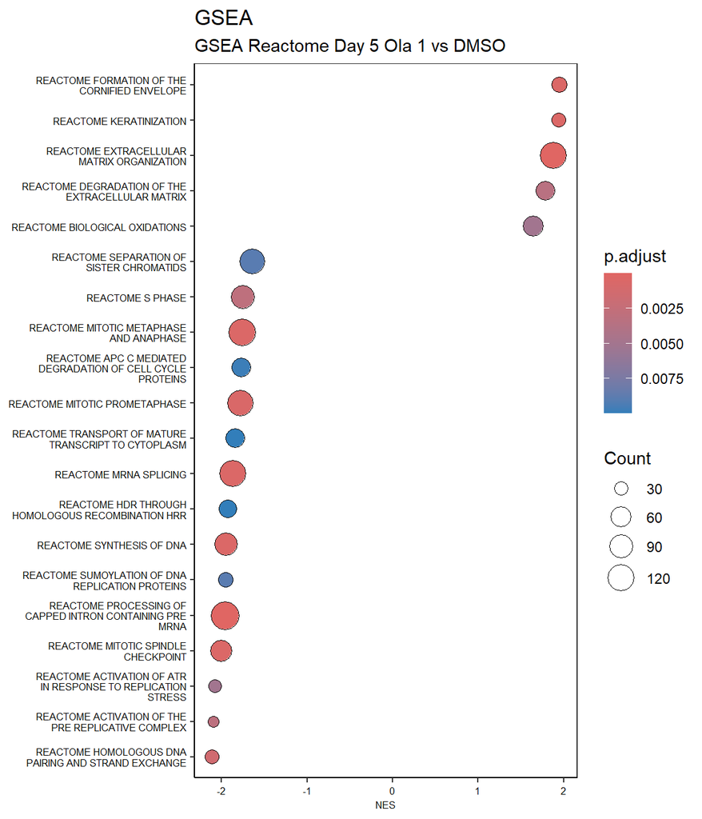

| ID | NES | setSize | p.adjust | qvalue | core_enrichment |
| --- | --- | --- | --- | --- | --- |
| REACTOME_FORMATION_OF_THE_CORNIFIED_ENVELOPE | 1.953416 | 87 | 0.0004501 | 0.0003955 | KRT17/KRT7/KRT35/KRT32/KRT36/KLK8/KRT9/FLG/KRT83/KRT79/IVL/KRT6A/LIPJ/KRT16/KRT6C/KRT6B/KRT14/KRT15/KRT72/TGM5/LCE1B/SPRR1A/KRT4/KRT3/KRT13/KRT24/PI3/KRT82/KRT80/KRT2/SPINK5/PRSS8/KLK12/KRT19/KRT8 |
| REACTOME_KERATINIZATION | 1.947474 | 101 | 0.0004323 | 0.0003799 | KRT17/KRT7/KRT35/KRT32/KRT36/KLK8/KRT9/FLG/KRT83/KRT79/KRTAP5-11/IVL/KRT6A/LIPJ/KRTAP5-7/KRT16/KRT6C/KRT6B/KRT14/KRT15/KRT72/TGM5/LCE1B/SPRR1A/KRT4/KRT3/KRT13/KRTAP19-5/KRT24/KRTAP5-10/PI3/KRT82 |
| REACTOME_EXTRACELLULAR_MATRIX_ORGANIZATION | 1.878011 | 274 | 0.0000014 | 0.0000012 | ITGAM/MUSK/ADAMTS5/COL17A1/ADAM19/COL28A1/PECAM1/COL4A1/MMP2…… |
| REACTOME_INTRINSIC_PATHWAY_OF_FIBRIN_CLOT_FORMATION | 1.832687 | 22 | 0.0269462 | 0.0236798 | GP1BA/SERPIND1/KNG1/GP5/SERPINE2/F10/SERPINA5/KLKB1/SERPING1/PROC |
| REACTOME_DEGRADATION_OF_THE_EXTRACELLULAR_MATRIX | 1.791196 | 122 | 0.0033817 | 0.0029718 | ADAMTS5/COL17A1/COL4A1/MMP2/BCAN/LAMC2/COL14A1/ADAMTS16/COL1…… |
| REACTOME_ARACHIDONIC_ACID_METABOLISM | 1.763851 | 54 | 0.0138717 | 0.0121902 | CYP1A2/DPEP1/CYP4B1/AKR1C3/PON3/CYP4F3/PTGS1/CYP4F8/PTGS2/HPGDS/CYP4F2/CYP1A1/DPEP2/ALOX5AP/PTGIS/PON1/DPEP3/CYP2U1/GGT5/ALOX12B/HPGD |
| REACTOME_SIGNALING_BY_NODAL | 1.763546 | 22 | 0.0450520 | 0.0395907 | CFC1/NODAL/GDF1/DAND5/ACVR1C/LEFTY1 |
| REACTOME_VISUAL_PHOTOTRANSDUCTION | 1.678504 | 88 | 0.0195088 | 0.0171439 | DHRS9/GRK7/AKR1B10/RBP4/AKR1C3/AWAT2/TTR/ABCA4/PLB1/BCO1/GNGT1/PDE6G/PDE6A/GUCY2F/RHO/CNGB1/RDH12/RBP1/MYO7A/PNLIP/LRP2/PRKCA/OPN1SW/SDC3/GNAT1/LRP1/SDC2/SDR9C7 |
| REACTOME_FATTY_ACID_METABOLISM | 1.650895 | 164 | 0.0138717 | 0.0121902 | CYP1A2/DPEP1/CYP4B1/AKR1C3/PON3/CYP4F3/PTGS1/CYP4F8/ACOT12/P…… |
| REACTOME_BIOLOGICAL_OXIDATIONS | 1.648143 | 204 | 0.0050686 | 0.0044542 | UGT1A10/UGT1A3/CYP2W1/ACSM5/CYP3A4/CYP3A5/SULT1B1/CYP1A2/CYP…… |
| REACTOME_PHASE_I_FUNCTIONALIZATION_OF_COMPOUNDS | 1.626782 | 98 | 0.0315402 | 0.0277168 | CYP2W1/CYP3A4/CYP3A5/CYP1A2/CYP3A43/ADH7/ADH4/ADH6/CYP4B1/CYP4F3/CYP2A6/PTGS1/CYP4F8/CYP4F12/CYP3A7/NR1H4/CYP4F2/CYP1A1/AOC1/FDXR/PTGIS/AADAC/FMO2/CYP2U1/ALDH3A1/CES3/AHRR/CYP2E1/ARNT2/ADH1C |
| REACTOME_INTEGRIN_CELL_SURFACE_INTERACTIONS | 1.616697 | 82 | 0.0434027 | 0.0381414 | ITGAM/PECAM1/COL4A1/COL10A1/VTN/ICAM4/THBS1/ICAM2/IBSP/ITGB3…… |
| REACTOME_MUSCLE_CONTRACTION | 1.613311 | 177 | 0.0138717 | 0.0121902 | MYBPC2/ACTA2/MYBPC3/SCN4A/KCNK3/SCN11A/FXYD2/ATP2B2/ANXA1/SL…… |
| REACTOME_SENSORY_PERCEPTION | 1.517922 | 212 | 0.0242304 | 0.0212932 | DHRS9/CNGA4/TAS2R38/OR3A1/MYO3B/CALHM1/GRK7/XIRP2/ATP2B2/AKR…… |
| REACTOME_M_PHASE | -1.403232 | 378 | 0.0195088 | 0.0171439 | CEP41/ANKLE2/TUBB4B/PAFAH1B1/MAPRE1/PPP2R1B/H3C2/PSMD14/MAPK1/PSMB2/NUP210/PSMA1/CSNK2A2/KPNB1/CDC26/AAAS/H3C12/ANAPC15/TNPO1/NUP133/PSMC6/CEP290/NUDC/NUP58/SEC13/PSMD11/H3-3B/PMF1/PSMB6/CDC27/CEP43/P… |
| REACTOME_CELL_CYCLE_CHECKPOINTS | -1.503642 | 266 | 0.0195088 | 0.0171439 | PAFAH1B1/MAPRE1/PPP2R1B/PSMD14/PSMB2/PSMA1/CDC26/ANAPC15/NUP…… |
| REACTOME_SEPARATION_OF_SISTER_CHROMATIDS | -1.636067 | 178 | 0.0089053 | 0.0078258 | KIF2A/PSMC2/PSMD10/PSMD7/WAPL/TUBA4A/PPP2R5E/PSMC1/TUBB4B/PA…… |
| REACTOME_RESOLUTION_OF_SISTER_CHROMATID_COHESION | -1.652780 | 121 | 0.0195088 | 0.0171439 | NUP133/NUDC/SEC13/PMF1/CENPL/CENPP/TUBA8/CENPC/CLASP2/SEH1L/…… |
| REACTOME_TRNA_PROCESSING | -1.674212 | 108 | 0.0188466 | 0.0165620 | NUP214/TYW5/TRMT12/RTRAF/POP7/URM1/POP1/QTRT1/TYW1/PRORP/CTU…… |
| REACTOME_ORC1_REMOVAL_FROM_CHROMATIN | -1.743855 | 63 | 0.0369965 | 0.0325117 | PSMC5/PSMA4/PSMD3/RBX1/PSMD6/UBC/PSMA5/PSMD5/PSMA2/PSMB7/PSM…… |
| REACTOME_SWITCHING_OF_ORIGINS_TO_A_POST_REPLICATIVE_STATE | -1.748524 | 83 | 0.0137666 | 0.0120978 | PSMC5/PSMA4/PSMD3/RBX1/PSMD6/UBC/ANAPC16/PSMA5/PSMD5/PSMA2/A…… |
| REACTOME_RNA_POLYMERASE_II_TRANSCRIPTION_TERMINATION | -1.750541 | 64 | 0.0195088 | 0.0171439 | LSM10/WDR33/RNPS1/U2AF2/NCBP1/PABPN1/RBM8A/DHX38/SARNP/PCF11…… |
| REACTOME_S_PHASE | -1.752257 | 152 | 0.0029921 | 0.0026294 | PSMD1/PSMD12/PSMC2/PSMD10/PSMD7/WAPL/PSMC1/RB1/CCNH/PSMD14/P…… |
| REACTOME_EXTENSION_OF_TELOMERES | -1.755515 | 49 | 0.0450520 | 0.0395907 | RTEL1/RFC1/POLD1/SHQ1/CHTF18/DKC1/PPP6C/GAR1/RPA1/RPA2/RPA3/TERF1/PRIM2/POLA2/RFC2/PCNA/FEN1/CDK2/DNA2/RFC5/WRAP53/RFC3/TERT/CCNA1/POLA1/POLD3/RFC4/DSCC1/CCNA2/BLM/PIF1/PRIM1 |
| REACTOME_MITOTIC_METAPHASE_AND_ANAPHASE | -1.762668 | 221 | 0.0004323 | 0.0003799 | KIF2A/PSMC2/PSMD10/PSMD7/SPAST/WAPL/TUBA4A/PPP2R5E/PSMC1/ANK…… |
| REACTOME_SUMOYLATION_OF_DNA_DAMAGE_RESPONSE_AND_REPAIR_PROTEINS | -1.764503 | 72 | 0.0195088 | 0.0171439 | TPR/TDG/RAE1/SUMO3/SCMH1/PARP1/NUP210/AAAS/NUP133/SUMO2/NUP5…… |
| REACTOME_APC_C_MEDIATED_DEGRADATION_OF_CELL_CYCLE_PROTEINS | -1.766239 | 80 | 0.0097421 | 0.0085611 | PSMC5/PSMA4/PSMD3/PSMD6/UBC/ANAPC16/PSMA5/PSMD5/PSMA2/ANAPC7…… |
| REACTOME_MITOTIC_PROMETAPHASE | -1.781039 | 189 | 0.0006153 | 0.0005407 | NUP133/CEP290/NUDC/SEC13/PMF1/CEP43/CEP76/CENPL/EML4/NEK7/CE…… |
| REACTOME_POLO_LIKE_KINASE_MEDIATED_EVENTS | -1.801299 | 16 | 0.0421813 | 0.0370680 | CDC25A/LIN52/PKMYT1/WEE1/FOXM1/LIN54/CCNB1/CDC25C/MYBL2/CCNB2/LIN9/CENPF/PLK1 |
| REACTOME_INTERACTIONS_OF_VPR_WITH_HOST_CELLULAR_PROTEINS | -1.802834 | 37 | 0.0336304 | 0.0295536 | TPR/RAE1/HMGA1/NUP210/AAAS/NUP133/NUP58/SEC13/NUP62/SEH1L/NUP153/SLC25A5/NUP54/NUP43/NUP88/NUP107/NUP160/NUP205/NUP50/PSIP1/NUP85/NUP188/NUP37/NUP155/NDC1/NUP35/NUP93 |
| REACTOME_NUCLEAR_PORE_COMPLEX_NPC_DISASSEMBLY | -1.810013 | 36 | 0.0369965 | 0.0325117 | TPR/RAE1/NUP210/AAAS/NUP133/NUP58/SEC13/NEK7/NUP62/SEH1L/CDK1/NUP153/NUP54/NUP43/NUP88/NUP107/NUP160/NUP205/NUP50/NUP85/NUP188/NUP37/NUP155/CCNB1/NDC1/CCNB2/NUP35/NUP93 |
| REACTOME_SNRNP_ASSEMBLY | -1.817560 | 52 | 0.0195088 | 0.0171439 | PRMT5/DDX20/TGS1/TPR/NCBP1/RAE1/GEMIN5/SNRPE/NUP210/AAAS/NUP…… |
| REACTOME_TRANSPORT_OF_THE_SLBP_DEPENDANT_MATURE_MRNA | -1.820955 | 36 | 0.0342732 | 0.0301186 | TPR/NCBP1/RAE1/NUP210/AAAS/NUP133/NUP58/SEC13/SLBP/NUP62/SEH1L/NUP153/NUP54/NUP43/NUP88/NUP107/NUP160/NUP205/NUP50/NUP85/NUP188/NUP37/ALYREF/NUP155/NDC1/NUP35/NUP93 |
| REACTOME_G1_S_SPECIFIC_TRANSCRIPTION | -1.830164 | 29 | 0.0314882 | 0.0276712 | E2F6/TFDP1/CDK1/DHFR/CDC25A/TYMS/PCNA/CDT1/LIN52/CDC6/ORC1/RRM2/LIN54/CCNA1/FBXO5/POLA1/E2F1/TK1/LIN9/RBL1/CDC45 |
| REACTOME_SUMOYLATION_OF_SUMOYLATION_PROTEINS | -1.836286 | 35 | 0.0342732 | 0.0301186 | TPR/RAE1/NUP210/AAAS/NUP133/SUMO2/NUP58/SEC13/NUP62/UBE2I/SEH1L/NUP153/NUP54/NUP43/NUP88/NUP107/NUP160/NUP205/NUP50/NUP85/NUP188/NUP37/NUP155/NDC1/NUP35/NUP93 |
| REACTOME_TRANSPORT_OF_MATURE_TRANSCRIPT_TO_CYTOPLASM | -1.840629 | 82 | 0.0099500 | 0.0087439 | U2AF2/TPR/NCBP1/RAE1/RBM8A/DHX38/SARNP/NUP210/FIP1L1/GLE1/AA…… |
| REACTOME_SUMOYLATION_OF_RNA_BINDING_PROTEINS | -1.842675 | 45 | 0.0195088 | 0.0171439 | TPR/RAE1/SCMH1/NUP210/AAAS/HNRNPK/NUP133/SUMO2/NUP58/SEC13/NUP62/UBE2I/CBX2/SEH1L/HNRNPC/CBX4/NUP153/NUP54/NUP43/NUP88/NUP107/NUP160/NUP205/NUP50/BMI1/NUP85/NUP188/NUP37/NUP155/NDC1/NUP35/NUP93 |
| REACTOME_TRANSPORT_OF_MATURE_MRNAS_DERIVED_FROM_INTRONLESS_TRANSCRIPTS | -1.855191 | 42 | 0.0228919 | 0.0201169 | TPR/NCBP1/RAE1/NUP210/FIP1L1/AAAS/NUP133/NUP58/SEC13/SLBP/NUP62/SEH1L/CPSF4/NUP153/CPSF3/CPSF2/NUP54/NUP43/NUP88/NUP107/NUP160/NUP205/NUP50/NUP85/NUP188/NUP37/ALYREF/NUP155/NDC1/NUP35/NUP93 |
| REACTOME_EXPORT_OF_VIRAL_RIBONUCLEOPROTEINS_FROM_NUCLEUS | -1.858747 | 32 | 0.0369965 | 0.0325117 | TPR/RAE1/NUP210/AAAS/NUP133/NUP58/SEC13/NUP62/RAN/SEH1L/NUP153/NUP54/NUP43/XPO1/NUP88/NUP107/NUP160/NUP205/NUP50/NUP85/NUP188/NUP37/NUP155/NDC1/NUP35/NUP93 |
| REACTOME_DISEASES_OF_DNA_REPAIR | -1.867708 | 33 | 0.0228919 | 0.0201169 | MUTYH/NTHL1/MSH2/KAT5/MLH1/PALB2/RAD51D/RAD51B/MSH6/RAD51C/RMI2/RMI1/MRE11/DNA2/RAD51/BRCA1/XRCC2/EXO1/RBBP8/BRIP1/BRCA2/NEIL3/RAD51AP1/BARD1/BLM |
| REACTOME_MRNA_SPLICING | -1.869833 | 176 | 0.0004323 | 0.0003799 | SF3B1/ZCRB1/BUD31/PDCD7/POLR2J/PRPF40A/SNRPD3/AQR/SNRPD2/SNR…… |
| REACTOME_POSTMITOTIC_NUCLEAR_PORE_COMPLEX_NPC_REFORMATION | -1.878480 | 27 | 0.0195088 | 0.0171439 | KPNB1/TNPO1/NUP133/NUP58/SEC13/NUP62/RAN/UBE2I/SEH1L/NUP54/NUP43/NUP107/NUP160/NUP205/NUP85/NUP188/NUP37/NUP155/NDC1/RCC1/NUP35/NUP93 |
| REACTOME_NUCLEAR_IMPORT_OF_REV_PROTEIN | -1.891988 | 34 | 0.0195088 | 0.0171439 | TPR/RAE1/NUP210/KPNB1/AAAS/NUP133/NUP58/SEC13/NUP62/RAN/SEH1L/NPM1/NUP153/NUP54/NUP43/NUP88/NUP107/NUP160/NUP205/NUP50/NUP85/NUP188/NUP37/NUP155/NDC1/RCC1/NUP35/NUP93 |
| REACTOME_RESOLUTION_OF_D_LOOP_STRUCTURES_THROUGH_SYNTHESIS_DEPENDENT_STRAND_ANNEALING_SDSA | -1.896388 | 25 | 0.0232093 | 0.0203958 | KAT5/RTEL1/PALB2/RAD51D/RAD51B/RAD51C/RMI2/RMI1/MRE11/XRCC3/DNA2/RAD51/BRCA1/XRCC2/EXO1/RBBP8/BRIP1/BRCA2/RAD51AP1/BARD1/BLM |
| REACTOME_INTERACTIONS_OF_REV_WITH_HOST_CELLULAR_PROTEINS | -1.924232 | 37 | 0.0138717 | 0.0121902 | TPR/RAE1/NUP210/KPNB1/AAAS/NUP133/NUP58/SEC13/NUP62/RAN/SEH1L/NPM1/NUP153/NUP54/NUP43/XPO1/NUP88/NUP107/NUP160/RANBP1/NUP205/NUP50/NUP85/NUP188/NUP37/NUP155/NDC1/RCC1/NUP35/NUP93 |
| REACTOME_HDR_THROUGH_HOMOLOGOUS_RECOMBINATION_HRR | -1.924316 | 65 | 0.0099500 | 0.0087439 | KAT5/RTEL1/SPIDR/RFC1/POLD1/POLK/PALB2/RAD9A/RHNO1/RPA1/POLE…… |
| REACTOME_SYNTHESIS_OF_DNA | -1.946899 | 112 | 0.0004501 | 0.0003955 | PSMA4/PSMD3/RBX1/PSMD6/UBC/ANAPC16/LIG1/PSMA5/PSMD5/PSMA2/PO…… |
| REACTOME_SUMOYLATION_OF_DNA_REPLICATION_PROTEINS | -1.952395 | 46 | 0.0088999 | 0.0078210 | TPR/RAE1/SUMO3/NUP210/AAAS/NUP133/SUMO2/NUP58/SEC13/NUP62/UB…… |
| REACTOME_DNA_STRAND_ELONGATION | -1.954846 | 32 | 0.0165377 | 0.0145330 | RFC1/POLD1/RPA1/MCM3/RPA2/RPA3/PRIM2/POLA2/GINS3/RFC2/PCNA/FEN1/MCM4/MCM6/MCM2/DNA2/RFC5/RFC3/GINS2/MCM5/POLA1/POLD3/MCM7/RFC4/GINS4/GINS1/MCM8/CDC45/PRIM1 |
| REACTOME_PROCESSING_OF_CAPPED_INTRON_CONTAINING_PRE_MRNA | -1.961432 | 229 | 0.0000014 | 0.0000012 | SNRNP200/XAB2/POLR2D/WDR33/RNPS1/POLR2G/EFTUD2/DDX23/SF3B2/U…… |
| REACTOME_HDR_THROUGH_SINGLE_STRAND_ANNEALING_SSA | -1.964496 | 35 | 0.0137666 | 0.0120978 | KAT5/RAD9A/RHNO1/RPA1/RAD9B/RPA2/RPA3/RAD1/RFC2/RMI2/RMI1/TOPBP1/MRE11/DNA2/RAD51/RFC5/RFC3/BRCA1/EXO1/RFC4/RBBP8/BRIP1/BARD1/BLM |
| REACTOME_MITOTIC_SPINDLE_CHECKPOINT | -2.000108 | 106 | 0.0004323 | 0.0003799 | PAFAH1B1/MAPRE1/PPP2R1B/CDC26/ANAPC15/NUP133/NUDC/SEC13/PMF1…… |
| REACTOME_ACTIVATION_OF_ATR_IN_RESPONSE_TO_REPLICATION_STRESS | -2.070814 | 36 | 0.0050686 | 0.0044542 | RAD9A/RPA1/MCM3/RAD9B/RPA2/RPA3/RAD1/CDC25A/RFC2/MCM4/CDK2/ORC6/MCM6/MCM2/CDC6/ORC1/RFC5/RFC3/DBF4/CDC7/MCM5/CDC25C/CLSPN/CHEK1/MCM7/RFC4/MCM10/MCM8/CDC45 |
| REACTOME_ACTIVATION_OF_THE_PRE_REPLICATIVE_COMPLEX | -2.092661 | 33 | 0.0031412 | 0.0027604 | RPA1/MCM3/POLE3/RPA2/POLE/RPA3/PRIM2/POLA2/RPA4/MCM4/GMNN/CDT1/CDK2/ORC6/MCM6/MCM2/CDC6/ORC1/DBF4/CDC7/MCM5/POLA1/MCM7/POLE2/MCM10/MCM8/CDC45/PRIM1 |
| REACTOME_HOMOLOGOUS_DNA_PAIRING_AND_STRAND_EXCHANGE | -2.110339 | 40 | 0.0014751 | 0.0012963 | PALB2/RAD9A/RHNO1/RPA1/RAD51D/RAD9B/RPA2/RPA3/RAD1/RAD51B/RFC2/RAD51C/RMI2/RMI1/TOPBP1/MRE11/XRCC3/DNA2/RAD51/RFC5/RFC3/BRCA1/XRCC2/EXO1/CHEK1/RFC4/RBBP8/BRIP1/BRCA2/RAD51AP1/BARD1/BLM |

### Hallmark

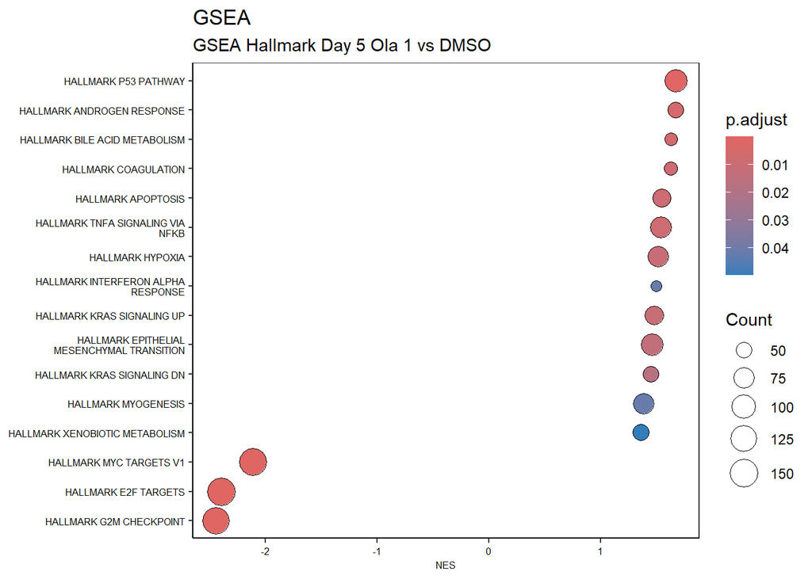

| ID | NES | setSize | p.adjust | qvalue | core_enrichment |
| --- | --- | --- | --- | --- | --- |
| HALLMARK_P53_PATHWAY | 1.672667 | 196 | 0.0005604 | 0.0002714 | KRT17/KLK8/CASP1/CDKN1A/CCND2/LIF/FAS/NDRG1/BTG2/PHLDA3/CDH1…… |
| HALLMARK_ANDROGEN_RESPONSE | 1.670826 | 99 | 0.0053756 | 0.0026029 | MAF/NDRG1/ADAMTS1/AZGP1/TMPRSS2/TSC22D1/AKAP12/MERTK/HSD17B14/MAK/SELENOP/SMS/ELOVL5/HPGD/HERC3/LIFR/ARID5B/STEAP4/SAT1/KRT19/KRT8/SORD/KLK2/GUCY1A1/ALDH1A3/HOMER2/GPD1L/FKBP5/PMEPA1/PTK2B/NKX3-1/PIAS… |
| HALLMARK_BILE_ACID_METABOLISM | 1.632720 | 107 | 0.0064779 | 0.0031367 | SOAT2/HAO1/SULT1B1/DIO2/TTR/ABCA4/DIO1/ABCG4/NR1H4/ABCA1/ACS…… |
| HALLMARK_COAGULATION | 1.625242 | 115 | 0.0084710 | 0.0041017 | GP1BA/PECAM1/THBD/MMP2/KLK8/ANXA1/TIMP1/THBS1/F10/CTSE/TMPRS…… |
| HALLMARK_APOPTOSIS | 1.543691 | 151 | 0.0084710 | 0.0041017 | MMP2/CASP1/GSTM1/CDKN1A/CCND2/ANXA1/TIMP1/SATB1/FAS/BCL2L10/…… |
| HALLMARK_TNFA_SIGNALING_VIA_NFKB | 1.538123 | 181 | 0.0084710 | 0.0041017 | CDKN1A/LIF/LAMB3/CXCL10/BTG2/ABCA1/PTGS2/CD44/TNC/CD80/RELB/…… |
| HALLMARK_HYPOXIA | 1.512132 | 187 | 0.0106698 | 0.0051665 | CCN5/SLC2A5/BCAN/CDKN1A/TGFBI/NCAN/MT1E/NDRG1/CSRP2/TKTL1/DT…… |
| HALLMARK_INTERFERON_ALPHA_RESPONSE | 1.496278 | 84 | 0.0416338 | 0.0201595 | RTP4/CASP1/GBP4/CXCL10/OAS1/UBA7/GBP2/NMI/CXCL11/TXNIP/IFIT2…… |
| HALLMARK_KRAS_SIGNALING_UP | 1.481596 | 181 | 0.0107571 | 0.0052087 | PECAM1/LY96/SCG3/H2BC3/GPNMB/CCND2/LIF/ETV1/CXCL10/RBP4/SATB…… |
| HALLMARK_EPITHELIAL_MESENCHYMAL_TRANSITION | 1.459554 | 189 | 0.0130787 | 0.0063329 | SFRP4/COL4A1/MMP2/ACTA2/LAMC2/NID2/TIMP1/THBS1/TGFBI/RGS4/FA…… |
| HALLMARK_KRAS_SIGNALING_DN | 1.448726 | 173 | 0.0172133 | 0.0083348 | GP1BA/MYH7/KLK8/GRID2/ATP4A/EPHA5/AKR1B10/CDH16/SMPX/DCC/BTG…… |
| HALLMARK_MYOGENESIS | 1.382064 | 181 | 0.0416338 | 0.0201595 | MYBPC3/KCNH1/MYH7/CDKN1A/CRYAB/MYBPH/CDH13/MYH3/DTNA/CAMK2B/…… |
| HALLMARK_XENOBIOTIC_METABOLISM | 1.362933 | 182 | 0.0497010 | 0.0240657 | CYP1A2/HSD17B2/ADH7/GCKR/VTN/RBP4/AKR1C3/FAS/F10/CYP17A1/PDK…… |
| HALLMARK_MYC_TARGETS_V1 | -2.110449 | 186 | 0.0000000 | 0.0000000 | RPL14/SLC25A3/ETF1/PRPS2/RPS3/CNBP/EIF3B/CCT3/IMPDH2/PSMA4/P…… |
| HALLMARK_E2F_TARGETS | -2.394954 | 194 | 0.0000000 | 0.0000000 | ORC2/XRCC6/MSH2/CNOT9/RFC1/SYNCRIP/SLBP/MLH1/CDKN1B/PAICS/SR…… |
| HALLMARK_G2M_CHECKPOINT | -2.443837 | 196 | 0.0000000 | 0.0000000 | CUL1/CDC27/NCL/CBX1/SYNCRIP/RPS6KA5/CDKN1B/SRSF2/KIF5B/ODC1/…… |

## GSEA Day5 Ola5

### GOBP

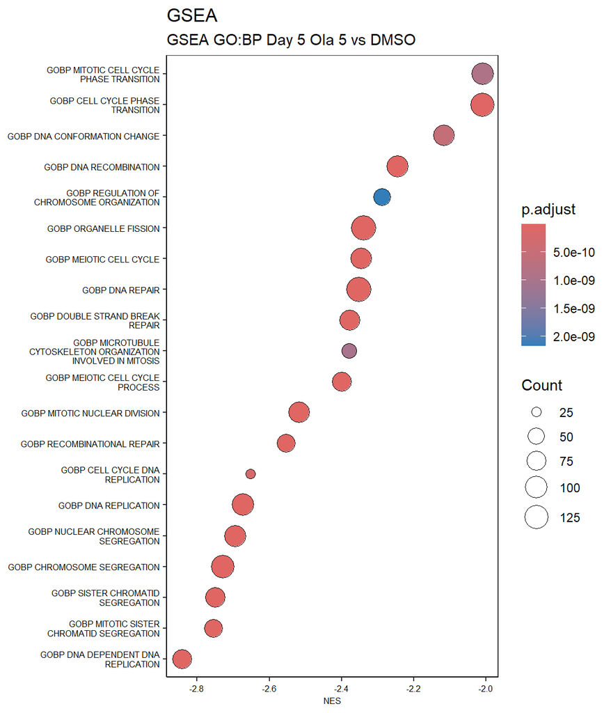

| ID | NES | setSize | p.adjust | qvalue | core_enrichment |
| --- | --- | --- | --- | --- | --- |
| GOBP_XENOBIOTIC_METABOLIC_PROCESS | 2.142348 | 98 | 0.0000011 | 0.0000009 | UGT1A3/UGT1A10/CYP3A5/CYP3A4/UGT1A8/CYP2W1/SULT1B1/NAT2/NOS1…… |
| GOBP_NEGATIVE_REGULATION_OF_REGULATED_SECRETORY_PATHWAY | 2.121237 | 24 | 0.0000664 | 0.0000527 | CEACAM1/LGALS9/FCGR2B/SYT4/FOXF1/CD300A/CCR2/ADRA2A/CD84/NCKAP1L/NOTCH1/HMOX1 |
| GOBP_KERATINIZATION | 2.120669 | 33 | 0.0001077 | 0.0000856 | KRT17/LCE1B/KRT16/IVL/CERS3/LCE1E/LCE3D/SPRR1A/SFN/KRT2/LCE4A/CNFN/ABCA12/HRNR |
| GOBP_NEGATIVE_REGULATION_OF_EXOCYTOSIS | 2.099529 | 34 | 0.0001980 | 0.0001572 | CEACAM1/LGALS9/FCGR2B/SYT4/FOXF1/ANXA1/CD300A/CCR2/ADRA2A/CD84/PRKN/NCKAP1L/NOTCH1/HMOX1 |
| GOBP_INTERMEDIATE_FILAMENT_ORGANIZATION | 2.081827 | 32 | 0.0002807 | 0.0002229 | KRT36/KRT17/KRT16/KRT35/KRT13/KRT15/KRT2/KLHL24/BFSP1/KRT14/KRT32/KRT71/VIM/NEFH/NEFL/KRT25 |
| GOBP_CATECHOLAMINE_SECRETION | 2.075000 | 48 | 0.0000841 | 0.0000668 | DRD2/SYT4/SYT2/CHRNA4/KCNB1/GDNF/CHRNB2/ADRA2A/SYT13/ADORA2A/KCNA2/SYT6/SYT3/PRKN/CARTPT/SNCG/ADRA2C/PINK1/SYT9/SYT17/VIP/SYT10/CHRNA6/SYT7/HRH3/ADORA3/ABAT |
| GOBP_GLYCOSIDE_METABOLIC_PROCESS | 2.070109 | 20 | 0.0003954 | 0.0003140 | GUSBP3/AKR1B10/AKR1C3/SULT1C4/AKR1C1/TH |
| GOBP_HOMOPHILIC_CELL_ADHESION_VIA_PLASMA_MEMBRANE_ADHESION_MOLECULES | 2.069824 | 162 | 0.0000003 | 0.0000003 | FAT3/PCDHA1/CLSTN2/CEACAM1/PCDHAC2/PCDHB15/CDHR4/PCDHB16/PCD…… |
| GOBP_FLAVONOID_METABOLIC_PROCESS | 2.047669 | 14 | 0.0002011 | 0.0001597 | UGT1A3/UGT1A10/UGT1A8/SULT1B1/UGT1A6/UGT1A7/SULT1C4/CYP1A1 |
| GOBP_DOPAMINE_SECRETION | 2.017308 | 32 | 0.0008123 | 0.0006451 | DRD2/SYT4/SYT2/CHRNA4/GDNF/CHRNB2/SYT13/KCNA2/SYT6/SYT3/PRKN/SNCG/PINK1/SYT9/SYT17/SYT10/CHRNA6/SYT7/ABAT |
| GOBP_DOPAMINE_TRANSPORT | 2.006178 | 42 | 0.0003689 | 0.0002929 | DRD2/SYT4/SYT2/CHRNA4/CHRM5/GDNF/CHRNB2/SYT13/KCNA2/SYT6/SYT3/PRKN/SNCG/PINK1/SYT9/SYT17/SLC6A2/SYT10/CHRNA6/SYT7/SLC29A4/ABAT |
| GOBP_NEGATIVE_REGULATION_OF_LEUKOCYTE_DEGRANULATION | 1.987807 | 13 | 0.0007468 | 0.0005931 | CEACAM1/LGALS9/FCGR2B/FOXF1/CD300A/CCR2/CD84/NCKAP1L/HMOX1 |
| GOBP_RESPONSE_TO_PROTOZOAN | 1.984612 | 19 | 0.0017362 | 0.0013787 | GBP6/GBP4/BATF/GBP2/VTCN1/IL12B/ARG1/IRF4/CLEC7A/BATF2 |
| GOBP_NEGATIVE_REGULATION_OF_CARTILAGE_DEVELOPMENT | 1.979241 | 25 | 0.0013878 | 0.0011020 | CCN4/WNT11/SOX9/GDF5/FRZB/PTH/ADAMTS7/WNT9A/NOG/SNAI2 |
| GOBP_MONOAMINE_TRANSPORT | 1.964887 | 69 | 0.0002550 | 0.0002025 | DRD2/SYT4/NOS1/SYT2/CHRNA4/CHRM5/KCNB1/GDNF/CHRNB2/ADRA2A/SY…… |
| GOBP_INTERMEDIATE_FILAMENT_BASED_PROCESS | 1.956913 | 55 | 0.0004085 | 0.0003244 | KRT36/KRT17/KRT16/KRT35/KRT13/KRT15/KRT6C/KRT2/KLHL24/BFSP1/KRT14/KRT32/KRT71/VIM/NEFH/NEFL/KRT25 |
| GOBP_RETINOIC_ACID_METABOLIC_PROCESS | 1.951345 | 31 | 0.0024181 | 0.0019202 | UGT1A3/ADH6/CYP3A5/CYP3A4/UGT1A8/CYP2W1/AKR1C3/UGT1A7/CYP1A1/DHRS9/CYP3A7/CYP26A1 |
| GOBP_CELL_CELL_ADHESION_VIA_PLASMA_MEMBRANE_ADHESION_MOLECULES | 1.949949 | 257 | 0.0000001 | 0.0000001 | ITGAM/FAT3/PCDHA1/CLSTN2/CEACAM1/PCDHAC2/PCDHB15/CDHR4/PCDHB…… |
| GOBP_REGULATION_OF_B_CELL_RECEPTOR_SIGNALING_PATHWAY | 1.938284 | 17 | 0.0033212 | 0.0026373 | CD22/NFAM1/FCGR2B/GCSAML/CD300A/FCRL3/LPXN/CMTM3 |
| GOBP_ORGANIC_HYDROXY_COMPOUND_TRANSPORT | 1.927410 | 235 | 0.0000012 | 0.0000010 | SLCO2B1/CEACAM1/DRD2/SOAT2/CEL/SLC5A1/AQP2/SYT4/NOS1/SYT2/SL…… |
| GOBP_CELLULAR_RESPONSE_TO_XENOBIOTIC_STIMULUS | 1.923642 | 151 | 0.0000192 | 0.0000152 | ANKRD1/UGT1A3/UGT1A10/CYP3A5/CYP3A4/UGT1A8/CYP2W1/SULT1B1/NA…… |
| GOBP_CELLULAR_DEFENSE_RESPONSE | 1.922786 | 40 | 0.0022696 | 0.0018023 | CXCR2/IL33/NCF2/LY96/DCDC2/CCR2/CD300C/CD5L/ADORA2A/IL1RL2/LGALS3BP/CX3CR1/PTK2B/CXCL9/CLEC5A |
| GOBP_PEPTIDE_CROSS_LINKING | 1.918970 | 29 | 0.0028993 | 0.0023023 | FLG/IVL/EPB42/THBS1/ANXA1/TGM5/EGFLAM/SPRR1A/PI3/KRT2/BGN/SPOCK2/COL3A1 |
| GOBP_EMBRYO_IMPLANTATION | 1.912327 | 52 | 0.0028348 | 0.0022510 | NODAL/LIF/EPO/A1CF/GJA1/TIMP1/TRO/UBTFL1/ACVR1C/TGFBR2/PCSK5/TPPP3/SYDE1/PTGS2/ARHGDIB/SCGB1A1/MMP2/PRDM14/IGFBP7 |
| GOBP_NEGATIVE_REGULATION_OF_ANTIGEN_RECEPTOR_MEDIATED_SIGNALING_PATHWAY | 1.911134 | 28 | 0.0022133 | 0.0017575 | CD22/CEACAM1/GBP1/FCGR2B/CD300A/FCRL3/LPXN/LAPTM5/THY1 |
| GOBP_REGULATION_OF_DENDRITE_EXTENSION | 1.910585 | 23 | 0.0076408 | 0.0060674 | RASAL1/SYT4/SYT2/RIMS2/CPNE5/SYT3/PRKN/CPNE9/UNC13A/SYT17 |
| GOBP_REGULATION_OF_ANTIGEN_RECEPTOR_MEDIATED_SIGNALING_PATHWAY | 1.908594 | 55 | 0.0009653 | 0.0007665 | CD22/CEACAM1/NFAM1/GBP1/FCGR2B/GCSAML/CD300A/FCRL3/LPXN/LAPTM5/KCNN4/CARD11/THY1/CMTM3 |
| GOBP_MONOCYTE_CHEMOTAXIS | 1.904380 | 45 | 0.0050629 | 0.0040203 | CXCL10/CCL26/SERPINE1/S100A14/ANXA1/CCN3/CCL24/SLAMF8/CCR2/CCL20/CCL8/LGMN/DUSP1/CX3CR1/DEFB124/CCL2/PTPRO/SLIT2/NBL1/CXCL17 |
| GOBP_SYNAPTIC_TRANSMISSION_DOPAMINERGIC | 1.901503 | 22 | 0.0043451 | 0.0034503 | DRD2/GDNF/CHRNB2/ADORA2A/TH/PRKN/SLC6A4/PTGS2/PINK1/SLC6A2/CRHBP/SNCA/RAB3B |
| GOBP_NEGATIVE_REGULATION_OF_MYELOID_LEUKOCYTE_MEDIATED_IMMUNITY | 1.895263 | 12 | 0.0031916 | 0.0025344 | LGALS9/FCGR2B/FOXF1/CD300A/CCR2/CD84/HMOX1/CX3CR1 |

[output cut: 511 more lines]

### Reactome

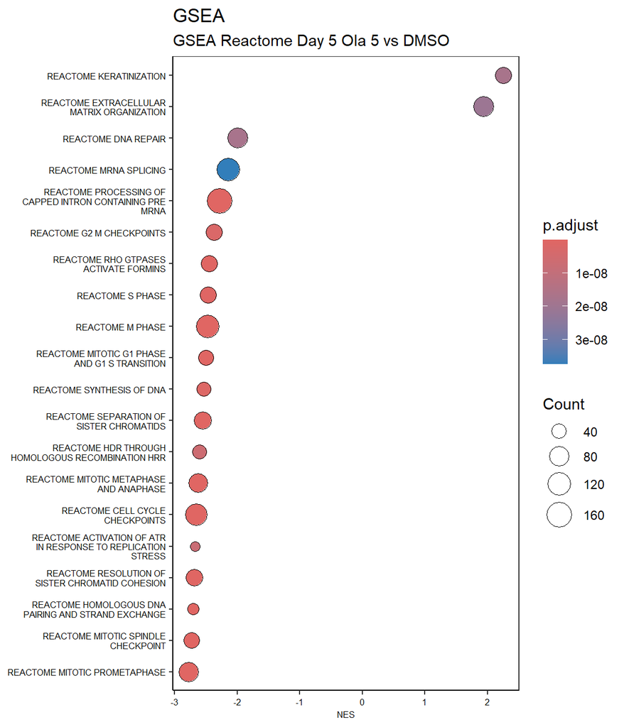

| ID | NES | setSize | p.adjust | qvalue | core_enrichment |
| --- | --- | --- | --- | --- | --- |
| REACTOME_KERATINIZATION | 2.251133 | 101 | 0.0000000 | 0.0000000 | KRT36/KRT17/LCE1B/FLG/KRT16/KRT6A/IVL/KRT35/KRTAP19-1/KRT7/KRT13/KRT6B/KRT82/KRTAP5-9/KRT15/LCE1E/TGM5/LCE3D/KRT78/SPRR1A/KLK13/PI3/KRT6C/KRT75/KRT5/KRT2/KRT14/KRT32/LCE4A/KRT71/KRTAP5-11/KRTAP13-2/KR… |
| REACTOME_FORMATION_OF_THE_CORNIFIED_ENVELOPE | 2.230886 | 87 | 0.0000004 | 0.0000003 | KRT36/KRT17/LCE1B/FLG/KRT16/KRT6A/IVL/KRT35/KRT7/KRT13/KRT6B…… |
| REACTOME_SURFACTANT_METABOLISM | 2.168406 | 29 | 0.0000184 | 0.0000146 | SLC34A2/DMBT1/PGA4/NAPSA/ADGRF5/ADRA2A/CSF2RB/SFTPA1/ADORA2A/ADA2/PGA5/SFTPA2/ADRA2C/SLC34A1 |
| REACTOME_DEGRADATION_OF_THE_EXTRACELLULAR_MATRIX | 1.981532 | 122 | 0.0000122 | 0.0000097 | COL17A1/ADAMTS16/ADAMTS5/LAMB3/BCAN/COL4A1/MMP12/LAMC2/CAPN6…… |
| REACTOME_CYTOCHROME_P450_ARRANGED_BY_SUBSTRATE_TYPE | 1.971032 | 60 | 0.0017021 | 0.0013559 | CYP3A5/CYP3A4/CYP4B1/CYP2W1/CYP1A2/CYP4F8/CYP3A43/CYP4F3/CYP4F12/CYP4F2/CYP2A6/CYP1A1/CYP3A7/FDXR/AHRR/CYP26A1/CYP2E1/CYP19A1/CYP2U1/ARNT2/PTGIS/CYP8B1 |
| REACTOME_PHASE_I_FUNCTIONALIZATION_OF_COMPOUNDS | 1.951767 | 98 | 0.0000282 | 0.0000225 | ADH6/CYP3A5/CYP3A4/CYP4B1/CYP2W1/CYP1A2/CYP4F8/ALDH3A1/CYP3A…… |
| REACTOME_ARACHIDONIC_ACID_METABOLISM | 1.946750 | 54 | 0.0011349 | 0.0009041 | CYP4B1/AKR1C3/CYP1A2/CYP4F8/CYP4F3/PTGS1/CYP4F2/ALOX5AP/CYP1A1/DPEP1/HPGDS/PTGS2/CYP2U1/PTGES/PTGIS/CYP8B1/PON3/DPEP3/TBXAS1/EPHX2/CYP2C9/CYP2J2/CYP1B1/GGT1/GPX2/GPX1/CYP4F22 |
| REACTOME_EXTRACELLULAR_MATRIX_ORGANIZATION | 1.940768 | 274 | 0.0000000 | 0.0000000 | COL17A1/ITGAM/CEACAM1/MUSK/COL28A1/ADAMTS14/ADAMTS16/VTN/SER…… |
| REACTOME_XENOBIOTICS | 1.923646 | 22 | 0.0028170 | 0.0022440 | CYP3A5/CYP3A4/CYP2W1/CYP1A2/CYP3A43/CYP2A6/CYP1A1/CYP3A7/AHRR/CYP2E1 |
| REACTOME_BIOLOGICAL_OXIDATIONS | 1.903112 | 204 | 0.0000016 | 0.0000013 | UGT1A3/UGT1A10/ADH6/CYP3A5/CYP3A4/UGT1A8/CYP4B1/CYP2W1/SULT1…… |
| REACTOME_SYNTHESIS_OF_LEUKOTRIENES_LT_AND_EOXINS_EX | 1.901915 | 18 | 0.0028377 | 0.0022605 | CYP4B1/CYP4F8/CYP4F3/CYP4F2/ALOX5AP/DPEP1 |
| REACTOME_INTRINSIC_PATHWAY_OF_FIBRIN_CLOT_FORMATION | 1.890921 | 22 | 0.0043374 | 0.0034552 | GP1BA/SERPIND1/SERPINA5/PROC/SERPINE2/KNG1/KLKB1/GP5/F10 |
| REACTOME_SENSORY_PERCEPTION_OF_TASTE | 1.886538 | 32 | 0.0063310 | 0.0050433 | SCNN1G/TAS2R5/TAS2R38/TRPM5/TAS2R4/SCNN1B/SCN3A/SCN9A/SCN1B/GNG13/SCN2B/SCN2A/TAS2R1 |
| REACTOME_VOLTAGE_GATED_POTASSIUM_CHANNELS | 1.869078 | 35 | 0.0057585 | 0.0045873 | KCNS2/KCNC2/KCNQ3/KCNB1/KCNA2/KCNB2/KCNAB1/KCNC3/KCNF1/KCNA1/KCNH3/KCNH4/KCNA7/KCNS1/KCNH7/KCNH5/KCNH1/KCNG2/KCNH2/KCND3/KCNH6/KCNC1/KCND1 |
| REACTOME_INTERACTION_BETWEEN_L1_AND_ANKYRINS | 1.855214 | 29 | 0.0055063 | 0.0043864 | ANK1/KCNQ3/NRCAM/NFASC/SCN3B/SCN4A/SCN3A/SCN9A/SCN1B/SCN1A/SCN2B/SCN2A/SPTBN1/SCN11A/SCN7A/SCN8A/L1CAM/SPTB/SPTBN5/SCN4B |
| REACTOME_POTASSIUM_CHANNELS | 1.851437 | 87 | 0.0013722 | 0.0010931 | KCNS2/KCNK3/KCNC2/KCNQ3/GABBR2/HCN4/KCNB1/KCNK13/KCNN4/KCNA2…… |
| REACTOME_ECM_PROTEOGLYCANS | 1.838112 | 73 | 0.0044983 | 0.0035834 | MUSK/VTN/SERPINE1/BCAN/TNR/COL4A1/TNC/LAMA2/ITGA9/TGFB2/COL5A1/TNN/IBSP/ITGB6/VCAN/NCAN/COL4A6/ACAN/COL4A5/BGN/LRP4/COL3A1/ITGAX/LAMC1/COL6A1/ITGA7/DMP1/COL1A2/DSPP/COL6A2/PTPRS/FN1/LAMA3/FMOD |
| REACTOME_COLLAGEN_CHAIN_TRIMERIZATION | 1.830685 | 42 | 0.0028170 | 0.0022440 | COL17A1/COL28A1/COL4A1/COL10A1/COL22A1/COL5A1/COL12A1/COL4A6/COL18A1/COL14A1/COL4A5/COL3A1/COL6A1/COL23A1/COL11A1/COL21A1/COL19A1/COL1A2/COL6A2/COL26A1/COL27A1 |
| REACTOME_DIGESTION_AND_ABSORPTION | 1.815370 | 22 | 0.0098230 | 0.0078251 | SLC2A5/CEL/SLC5A1/CHIT1/AMY2A/AMY2B/GUCY2C/LCT/TREH/NPC1L1 |
| REACTOME_MISCELLANEOUS_SUBSTRATES | 1.808700 | 11 | 0.0150394 | 0.0119805 | CYP4B1/CYP2W1/CYP3A43/CYP4F3/CYP4F2 |
| REACTOME_DERMATAN_SULFATE_BIOSYNTHESIS | 1.784406 | 10 | 0.0085888 | 0.0068419 | BCAN/CSPG4/VCAN/NCAN/BGN |
| REACTOME_ANTIMICROBIAL_PEPTIDES | 1.780317 | 38 | 0.0219379 | 0.0174760 | RNASE7/S100A9/DEFB1/CCR2/PI3/BPIFB1/SEMG1/S100A8/DEFB129/PLA2G2A/LYZ/DEFB132/LCN2/DEFB126/TLR2/CLU/DEFB124 |
| REACTOME_CHONDROITIN_SULFATE_BIOSYNTHESIS | 1.766258 | 20 | 0.0262615 | 0.0209201 | BCAN/CSPG4/VCAN/NCAN/CSGALNACT1/BGN/CHST9/CHPF/CHST13/CHPF2/CHST15/CHST11 |
| REACTOME_PHASE_0_RAPID_DEPOLARISATION | 1.763821 | 30 | 0.0261181 | 0.0208059 | CAMK2B/FGF14/FGF13/CAMK2A/SCN3B/SCN4A/SCN3A/SCN9A/SCN1B/SCN1A/SCN2B/SCN2A/SCN11A/SCN7A/SCN8A/CAMK2D/SCN4B |
| REACTOME_GLUCURONIDATION | 1.743000 | 20 | 0.0332281 | 0.0264698 | UGT1A3/UGT1A10/UGT1A8/UGT1A6/UGT1A7/UGT3A2 |
| REACTOME_COLLAGEN_DEGRADATION | 1.737790 | 55 | 0.0065278 | 0.0052001 | COL17A1/COL4A1/MMP12/MMP1/COL10A1/COL5A1/TMPRSS6/COL12A1/COL4A6/COL18A1/COL14A1/COL4A5/COL3A1/COL6A1/COL23A1/COL11A1/MMP2/COL19A1/COL1A2/COL6A2/CTSD/COL26A1 |
| REACTOME_FOXO_MEDIATED_TRANSCRIPTION_OF_CELL_CYCLE_GENES | 1.737338 | 17 | 0.0369914 | 0.0294677 | CDKN1A/GADD45A/MSTN/BTG1/KLF4/FOXO3/CCNG2/PCBP4 |
| REACTOME_INTERFERON_GAMMA_SIGNALING | 1.734113 | 66 | 0.0081075 | 0.0064585 | TRIM48/TRIM22/GBP6/GBP1/GBP4/OAS1/TRIM29/GBP3/CAMK2B/GBP2/CA…… |
| REACTOME_FATTY_ACIDS | 1.724706 | 12 | 0.0378420 | 0.0301453 | CYP4B1/CYP4F8/CYP4F3/CYP4F12/CYP4F2 |
| REACTOME_TYPE_I_HEMIDESMOSOME_ASSEMBLY | 1.717995 | 11 | 0.0378420 | 0.0301453 | COL17A1/LAMB3/LAMC2/KRT5/KRT14 |

[output cut: 146 more lines]

### Hallmark

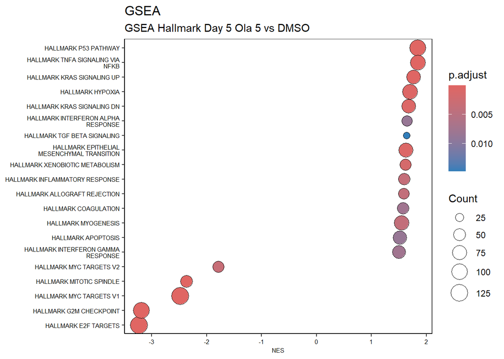

| ID | NES | setSize | p.adjust | qvalue | core_enrichment |
| --- | --- | --- | --- | --- | --- |
| HALLMARK_P53_PATHWAY | 1.847782 | 196 | 0.0000045 | 0.0000018 | KRT17/CDKN1A/LIF/FAS/BTG2/NDRG1/CCND2/FGF13/ZMAT3/GADD45A/PL…… |
| HALLMARK_TNFA_SIGNALING_VIA_NFKB | 1.846966 | 181 | 0.0000154 | 0.0000062 | CXCL10/CDKN1A/SERPINE1/LIF/LAMB3/CXCL11/RELB/TNC/BTG2/GADD45…… |
| HALLMARK_KRAS_SIGNALING_UP | 1.768724 | 181 | 0.0001034 | 0.0000414 | CXCL10/GPNMB/IL33/SATB1/LY96/H2BC3/LIF/SCG3/SOX9/TMEM176A/CC…… |
| HALLMARK_HYPOXIA | 1.700693 | 187 | 0.0004545 | 0.0001818 | SLC2A5/CDKN1A/DTNA/SERPINE1/BCAN/CHST2/TGFBI/NDRG1/EDN2/IGFB…… |
| HALLMARK_KRAS_SIGNALING_DN | 1.677244 | 173 | 0.0006023 | 0.0002409 | INSL5/SMPX/GP1BA/AKR1B10/NOS1/KRT13/CHST2/MYH7/KRT15/CAMK1D/…… |
| HALLMARK_INTERFERON_ALPHA_RESPONSE | 1.646098 | 84 | 0.0085671 | 0.0034268 | CXCL10/GBP4/RTP4/OAS1/UBA7/CXCL11/GBP2/IFIT3/TMEM140/IFIT2/O…… |
| HALLMARK_TGF_BETA_SIGNALING | 1.640058 | 49 | 0.0147504 | 0.0059002 | SERPINE1/THBS1/ENG/ID2/NOG/JUNB/ID1/SMAD7/SPTBN1/PPP1R15A/BMPR2/HIPK2/PMEPA1/LTBP2/FKBP1A/CDH1/KLF10/SMAD3/FURIN/TGIF1/BMPR1A/SMAD6/SKIL |
| HALLMARK_EPITHELIAL_MESENCHYMAL_TRANSITION | 1.626702 | 189 | 0.0006023 | 0.0002409 | ACTA2/SERPINE1/FAS/THBS1/COL4A1/TNC/TGFBI/RGS4/LAMC2/SERPINE…… |
| HALLMARK_XENOBIOTIC_METABOLISM | 1.617073 | 182 | 0.0014156 | 0.0005662 | HSD17B2/AKR1C3/VTN/SERPINE1/CYP1A2/GCKR/FAS/ALDH3A1/SLC12A4/…… |
| HALLMARK_ANGIOGENESIS | 1.609131 | 30 | 0.0303998 | 0.0121599 | VTN/SERPINA5/THBD/CCND2/TIMP1/VCAN/NRP1/COL3A1 |
| HALLMARK_INFLAMMATORY_RESPONSE | 1.598363 | 175 | 0.0036495 | 0.0014598 | CXCL10/GP1BA/CDKN1A/RTP4/SERPINE1/ITGB8/LIF/CXCL11/LCP2/GPR1…… |
| HALLMARK_ALLOGRAFT_REJECTION | 1.588486 | 152 | 0.0038351 | 0.0015341 | LY75/CRTAM/ZAP70/FCGR2B/LIF/FAS/LCP2/GBP2/IL13/CCND2/IL2RG/C…… |
| HALLMARK_COAGULATION | 1.575321 | 115 | 0.0076415 | 0.0030566 | GP1BA/CTSE/SERPINE1/THBS1/ANXA1/THBD/PROC/MMP1/TIMP1/HNF4A/S…… |
| HALLMARK_MYOGENESIS | 1.554192 | 181 | 0.0038351 | 0.0015341 | CDKN1A/MYL7/DTNA/NOS1/CRYAB/CAMK2B/MYH8/MYH2/MYH7/LAMA2/HSPB…… |
| HALLMARK_APOPTOSIS | 1.514166 | 151 | 0.0085671 | 0.0034268 | CDKN1A/SATB1/FAS/GSTM1/ANXA1/BTG2/CCND2/DPYD/TGFB2/GADD45A/T…… |
| HALLMARK_HEDGEHOG_SIGNALING | 1.513709 | 36 | 0.0495595 | 0.0198238 | NRCAM/CNTFR/RTN1/THY1/NRP1/NRP2/AMOT/SLIT1/VEGFA/L1CAM/TLE1/SCG2/PTCH1/CRMP1/HEY1/VLDLR/ADGRG1/UNC5C/LDB1/PML |
| HALLMARK_PANCREAS_BETA_CELLS | 1.512299 | 34 | 0.0495595 | 0.0198238 | NEUROG3/PCSK1/SYT13/SCGN/ABCC8/PAX4/NEUROD1/INSM1/PCSK2/PAK3/DCX/PAX6 |
| HALLMARK_INTERFERON_GAMMA_RESPONSE | 1.504627 | 171 | 0.0076415 | 0.0030566 | CXCL10/CDKN1A/GBP6/SLAMF7/XAF1/GBP4/RTP4/FAS/CXCL11/LCP2/MVP…… |
| HALLMARK_BILE_ACID_METABOLISM | 1.502142 | 107 | 0.0192391 | 0.0076957 | SOAT2/SULT1B1/HAO1/LIPE/NR0B2/TTR/ABCA1/DIO1/FDXR/HSD3B1/ACS…… |
| HALLMARK_ANDROGEN_RESPONSE | 1.448375 | 99 | 0.0321866 | 0.0128746 | NDRG1/MAF/HSD17B14/ADAMTS1/TMPRSS2/ALDH1A3/AZGP1/TSC22D1/SAT…… |
| HALLMARK_UV_RESPONSE_DN | 1.396097 | 134 | 0.0362098 | 0.0144839 | SERPINE1/CELF2/AMPH/RGS4/CACNA1A/KIT/GJA1/IGFBP5/F3/TGFBR2/PTPRM/KALRN/NR3C1/PRKCA/NRP1/SNAI2/ANXA2/COL3A1/CAP2/ID1/LAMC1/PIK3R3/DUSP1/SDC2/COL11A1/SMAD7/DLC1 |
| HALLMARK_HEME_METABOLISM | 1.377654 | 184 | 0.0303998 | 0.0121599 | CTSE/ANK1/EPB42/BTG2/ALDH1L1/UCP2/ADD2/ICAM4/RHD/OPTN/ACP5/P…… |
| HALLMARK_DNA_REPAIR | -1.364344 | 141 | 0.0321866 | 0.0128746 | RPA2/DUT/NUDT21/PDE4B/POLD1/RPA3/ALYREF/POLA1/SSRP1/RFC2/PCNA/CMPK2/TYMS/RFC5/POLA2/RFC3/FEN1/POLD3/RFC4/ZWINT/RAD51/PRIM1 |
| HALLMARK_MTORC1_SIGNALING | -1.374234 | 190 | 0.0204796 | 0.0081919 | WARS1/NUFIP1/LDLR/CCT6A/SQLE/HMBS/HSPE1/EIF2S2/NFYC/ME1/SSR1…… |
| HALLMARK_UNFOLDED_PROTEIN_RESPONSE | -1.493232 | 110 | 0.0192391 | 0.0076957 | EIF2S1/FKBP14/HSP90B1/EIF4G1/CNOT6/EIF4A1/PAIP1/PDIA6/POP4/N…… |
| HALLMARK_MYC_TARGETS_V2 | -1.788647 | 55 | 0.0033259 | 0.0013303 | NOLC1/HK2/MPHOSPH10/TFB2M/WDR43/RRP12/NOP16/RRP9/NIP7/IMP4/F…… |
| HALLMARK_MITOTIC_SPINDLE | -2.363250 | 186 | 0.0000000 | 0.0000000 | CKAP5/CDC42EP2/SMC1A/RFC1/CEP57/DST/KIF22/ARHGEF2/CNTRL/PREX…… |
| HALLMARK_MYC_TARGETS_V1 | -2.482498 | 186 | 0.0000000 | 0.0000000 | NOP16/RRP9/NME1/CCT2/GLO1/ETF1/NDUFAB1/SNRPD2/EIF4H/COPS5/AI…… |
| HALLMARK_G2M_CHECKPOINT | -3.186560 | 196 | 0.0000000 | 0.0000000 | KMT5A/SMC1A/ODF2/SFPQ/SLC7A1/NUP50/RPA2/KIF22/H2AZ2/SRSF1/AT…… |
| HALLMARK_E2F_TARGETS | -3.235907 | 194 | 0.0000000 | 0.0000000 | SMC1A/SLBP/RFC1/CSE1L/NUP205/NUP107/LYAR/RPA2/KIF22/DUT/ZW10…… |

### Summary

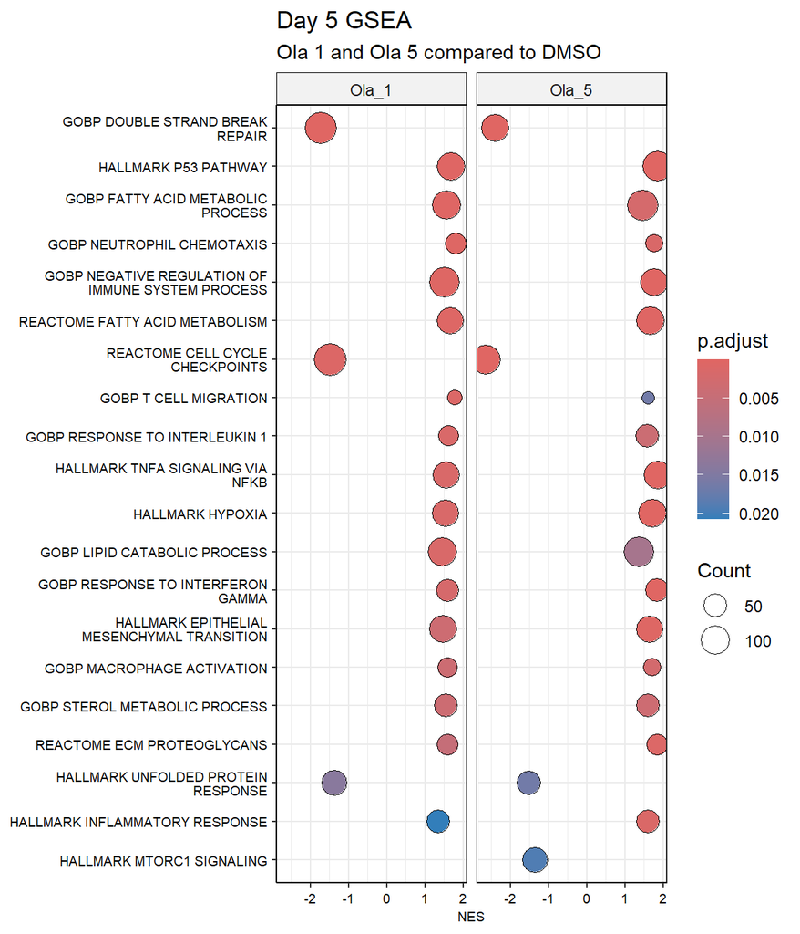

# Venn diagram on steroids (UpsetPlot)

Conditions we want to compare, per group:

- Ola 1 vs DMSO

- Ola 5 vs DMSO

I extracted all significantly differentially expressed genes (DEGs) for each condition (|log2Fc| >= 1 and pval < 0.05).

**Set size** = how many DEGs there are per sample

**Intersection size** = How many genes are shared between the x samples tied together with the bar + nodes

So if you sum up all the intersection size with a dot in a sample, you get the set size of that sample. It’s essentially a venn diagram for when you have >3 samples you want to compare.

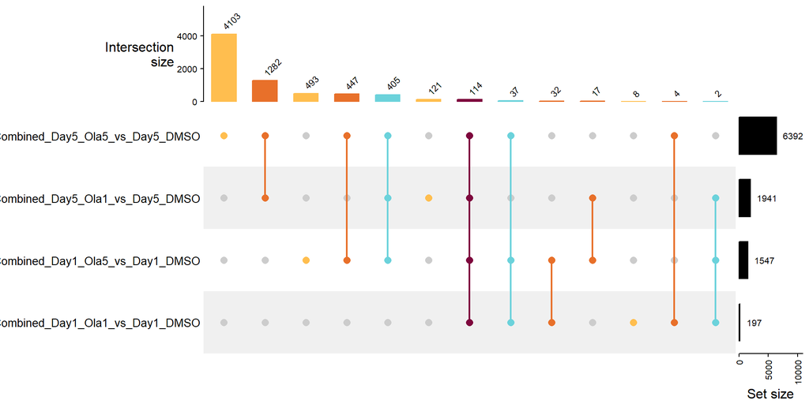